# Confirmatory Analyses: JEP: General

Preregistered analyses for experiment 5

Ian Hussey & Sean Hughes

12 April 2022

# Dependencies & functions

```r
# dependencies
library(tidyverse)
library(knitr)
library(kableExtra)
library(brms)
library(parallel)
library(tidybayes)
library(bayestestR)
library(sjPlot)
library(psych)
library(rsample)
library(broom)
library(purrr)
library(IATscores)
library(lavaan)
library(semTools)
library(modelr)
library(furrr)
library(caret)
library(e1071)

# set up parallel processing
future::plan(multiprocess)

# knitr options
options(knitr.kable.NA = "/")

# set seed for bootstrapping reproducibility
set.seed(42)

# create necessary folder
dir.create("models")
```

# Exclusions & standaridization

All dependent variables (self-reported evaluations and IAT D2 scores) were standardized (by 1 SD) after exclusions and prior to analysis condition (see Lorah, 2018: https://doi.org/10.1186/s40536-018-0061-2). This was done within each level of both IV (i.e., by Source Valence condition [positive vs. negative], and by Video Content [Genuine vs. Deepfaked]).

As such, the beta estimates obtained from the Bayesian models (see research questions and data analysis plans below) therefore represent standardized beta values ($\beta$ rather than $B$). More importantly, the nature of this standardization makes these estimates somewhat comparable to the frequentist standardized effect size metric Cohen’s $d$, as both are a differences in (estimated) means as a proportion of SD although they should not be treated as equivalent.

Effect size magnitude here can therefore be thought of along comparable scales as Cohen’s $d$. As such, to aid interpretability, the point estimates of effect size will be reported as $\delta$ (delta).

```r
# full data
data_processed <- read.csv("../data/processed/4_data_participant_level_with_hand_scoring.csv") %>%
  # include only experiment 7
  filter(experiment == 7) %>%
  # rename experiment so that it is consistent with what is reported in the manuscript (i.e., Experiment 5)
  mutate(experiment_renamed = case_when(experiment == 7 ~ 5)) %>%
  select(-experiment) %>%
  rename(experiment = experiment_renamed,
         informational_content = source_valence,
         content_type = experiment_condition) %>%
  relocate(experiment, .after = subject) %>%
  arrange(experiment) %>%


  # set factor levels for t test comparisons
  mutate(informational_content = fct_relevel(informational_content,
                                      "negative",
                                      "positive"),
         content_type = fct_relevel(content_type,
                                            "genuine",
                                            "deepfaked"),
         deepfake_detection_closed = fct_relevel(tolower(deepfake_detection_closed),
                                                 "genuine",
                                                 "deepfaked"),
         deepfake_awareness_closed = fct_relevel(deepfake_awareness_closed,
                                                 "unaware",
                                                 "aware"))

# apply exclusions
data_after_exclusions <- data_processed %>%
  filter(exclude_subject == FALSE &
           exclude_implausible_intervention_linger == FALSE) %>%
  # standardize DVs by 1SD within each experiment and their conditions
  group_by(experiment, content_type, informational_content) %>%
  mutate(mean_self_reported_evaluation = mean_self_reported_evaluation/sd(mean_self_reported_evaluation),
         IAT_D2 = IAT_D2/sd(IAT_D2),
         mean_intentions = mean_intentions/sd(mean_intentions)) %>%
  ungroup()

# item level for iat
data_iat_item_level_after_exclusions <- read_csv("../data/processed/2.4_data_iat_item_level.csv") %>%
  # exclude the same participants as above
  semi_join(rename(data_after_exclusions, subject_original = subject), by = "subject_original")
```

# Distributions

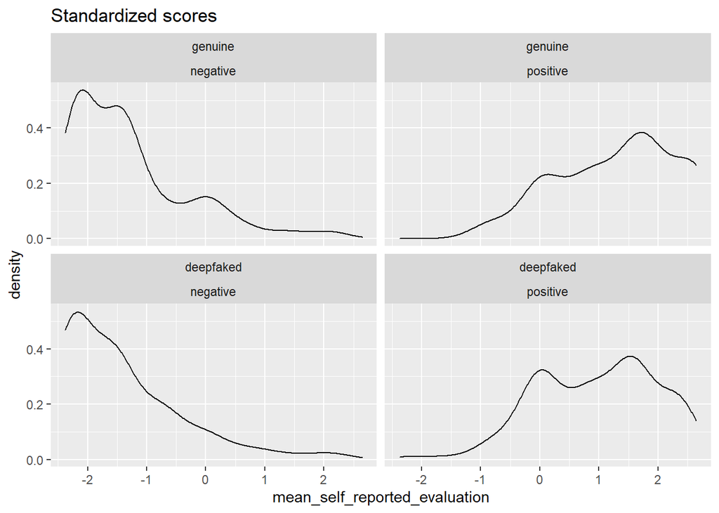

```r
ggplot(data_after_exclusions, aes(mean_self_reported_evaluation)) +
  geom_density() +
  facet_wrap( ~ content_type + informational_content) +
  ggtitle("Standardized scores")
```

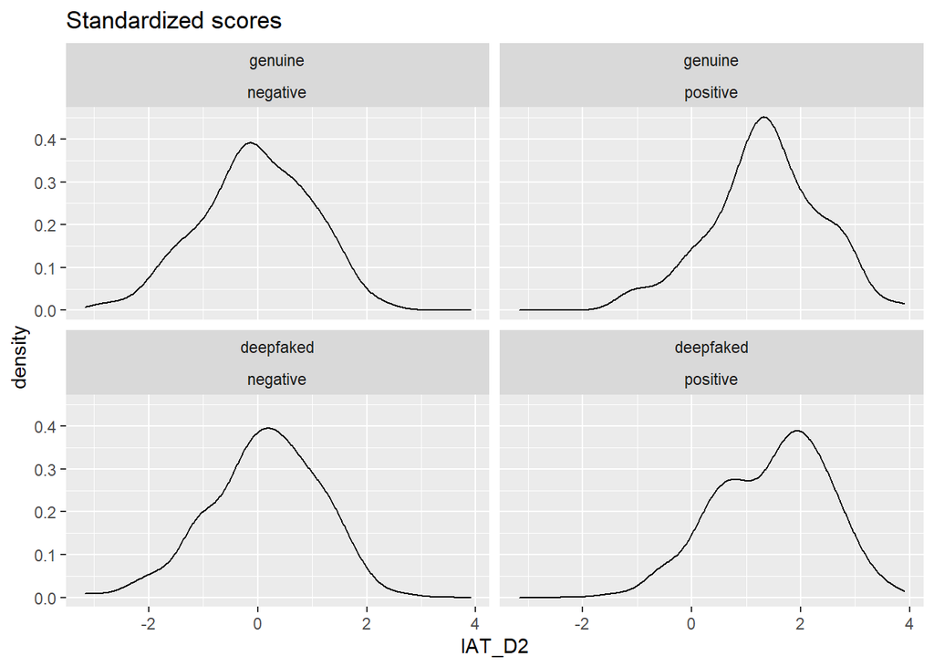

```r
ggplot(data_after_exclusions, aes(IAT_D2)) +
  geom_density() +
  facet_wrap( ~ content_type + informational_content) +
  ggtitle("Standardized scores")
```

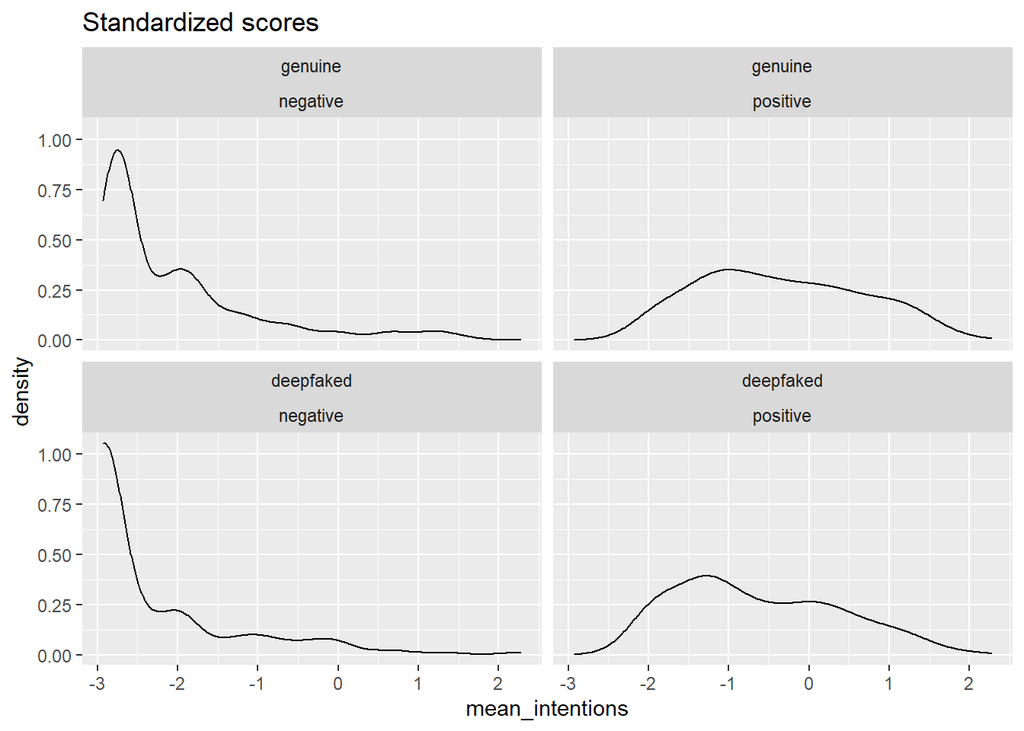

```r
ggplot(data_after_exclusions, aes(mean_intentions)) +
  geom_density() +
  facet_wrap( ~ content_type + informational_content) +
  ggtitle("Standardized scores")
```

# Demographics

## Pre exclussion

```r
data_processed %>%
  summarise(n = n(),
            excluded_n = sum(exclude_subject != FALSE |
                               exclude_implausible_intervention_linger != FALSE, na.rm = TRUE),
            excluded_percent = (excluded_n / n) *100) %>%
  mutate_if(is.numeric, round, digits = 1) %>%
  kable(align = "c") %>%
  kable_styling(bootstrap_options = c("striped", "hover", "condensed"),
                full_width = FALSE)
```

| n | excluded_n | excluded_percent |
| --- | --- | --- |
| 828 | 192 | 23.2 |

## Post exclusions

```r
data_after_exclusions %>%
  summarise(n = n(),
            age_mean = mean(age, na.rm = TRUE),
            age_sd = sd(age, na.rm = TRUE)) %>%
  mutate_if(is.numeric, round, digits = 1) %>%
  kable(align = "c") %>%
  kable_styling(bootstrap_options = c("striped", "hover", "condensed"),
                full_width = FALSE)
```

| n | age_mean | age_sd |
| --- | --- | --- |
| 635 | 35.7 | 13 |

```r
data_after_exclusions %>%
  count(gender) %>%
  spread(gender, n) %>%
  kable(knitr.kable.NA = "/", align = "c") %>%
  kable_styling(bootstrap_options = c("striped", "hover", "condensed"),
                full_width = FALSE)
```

| female | male | Non-binary | Prefer to self-discribe |
| --- | --- | --- | --- |
| 387 | 240 | 7 | 1 |

# Internal consistency

## Self-reported evaluations

```r
model_sr <- "scale =~ ratings_bad_good + ratings_dislike_like + ratings_negative_positive"

fit_cfa_sr <- data_after_exclusions %>%
  cfa(model = model_sr, data = .)

results_reliability_sr <- fit_cfa_sr %>%
  reliability() %>%
  as.data.frame() %>%
  rownames_to_column(var = "metric") %>%
  select(metric, estimate = scale) %>%
  filter(metric %in% c("alpha",
                       "omega2")) %>%
  mutate(metric = recode(metric,
                         "alpha" = "alpha",
                         "omega2" = "omega_t"),
         estimate = round(estimate, 3))

results_reliability_sr %>%
  kable(knitr.kable.NA = "/", align = "c") %>%
  kable_styling(bootstrap_options = c("striped", "hover", "condensed"),
                full_width = FALSE)
```

| metric | estimate |
| --- | --- |
| alpha | 0.987 |
| omega_t | 0.987 |

## IAT

split half

```r
results_iat_split_half_reliability <- data_iat_item_level_after_exclusions %>%
  SplitHalf.D2(IATdata = .) %>%
  mutate(algorithm = ifelse(algorithm == "p2112", "D2", algorithm),
         splithalf = round(splithalf, 3))
```

[output not shown]

```r
results_iat_split_half_reliability %>%
  kable(knitr.kable.NA = "/", align = "c") %>%
  kable_styling(bootstrap_options = c("striped", "hover", "condensed"),
                full_width = FALSE)
```

| algorithm | splithalf |
| --- | --- |
| D2 | 0.862 |

## Behavioral intentions

```r
model_bi <- "scale =~ behavioral_intentions_share + behavioral_intentions_subscribe + behavioral_intentions_recommend"

fit_cfa_bi <- data_after_exclusions %>%
  cfa(model = model_bi, data = .)

results_reliability_bi <- fit_cfa_bi %>%
  reliability() %>%
  as.data.frame() %>%
  rownames_to_column(var = "metric") %>%
  select(metric, estimate = scale) %>%
  filter(metric %in% c("alpha",
                       "omega2")) %>%
  mutate(metric = recode(metric,
                         "alpha" = "alpha",
                         "omega2" = "omega_t"),
         estimate = round(estimate, 3))

results_reliability_bi %>%
  kable(knitr.kable.NA = "/", align = "c") %>%
  kable_styling(bootstrap_options = c("striped", "hover", "condensed"),
                full_width = FALSE)
```

| metric | estimate |
| --- | --- |
| alpha | 0.939 |
| omega_t | 0.939 |

# H1: Can online content change attitudes and intentions?

# H2: Are Deepfakes as effective as genuine online content in changing attitudes and intentions?

- Analyses employ Bayesian linear models with informational_content (positive vs negative information about the target), content_type (authentic vs. deepfaked video) and their interaction as IVs. This could therefore be described as akin to a Bayesian ANOVA.
- DVs were standardize as noted above. Fitted model estimates represent standardized beta values (which due to the specifics of the standardization have comparable [but not exact] interpretation as Cohen’s d values).
- Bayesian p values are also reported: these are on a similar scale to frequentist p values, but technically are 1 minus the posterior probability that the effect is greater than 0, i.e., $1 - P(\beta>0)$.
- Inspection of the posterior distributions allow us to infer that we employed weak priors placed on all parameters (normal distribution with M = 0 and SD = 10). Inspection of the chains indicated good convergence in all cases.

H1 hypotheses were tested using a Bayesian linear model to estimate a 95% Credible Interval on standardized effect size change in attitudes and intentions between informational content (positive vs. negative) conditions. Credible Intervals whose lower bounds were > 0 were considered evidence in support of a given hypothesis.

For H2, if the lower bound of the 95% CI of the authentic video condition is < the lower bound of the 90% CI of the Deepfaked video condition (i.e., the difference between informational content conditions in each subgroups), this as considered evidence in support of the alternative hypothesis (i.e., evidence of non-inferiority in estimated means; that Deepfakes are as good as genuine content in changing attitudes and intentions).

## Sample sizes

```r
data_after_exclusions %>%
  select(informational_content,
         content_type) %>%
  drop_na() %>%
  count(content_type,
        informational_content) %>%
  kable() %>%
  kable_styling(bootstrap_options = c("striped", "hover", "condensed"),
                full_width = FALSE)
```

| content_type | informational_content | n |
| --- | --- | --- |
| genuine | negative | 155 |
| genuine | positive | 149 |
| deepfaked | negative | 160 |
| deepfaked | positive | 171 |

## Self-reported attitudes and intentions

### Fit model

```r
fit_confirmatory_selfreport <-
  brm(formula = mean_self_reported_evaluation ~ informational_content * content_type,
      family = gaussian(),
      data    = data_after_exclusions,
      file    = "models/fit_confirmatory_selfreport",
      prior   = prior(normal(0, 10)),
      iter    = 10000,
      warmup  = 3000,
      control = list(adapt_delta = 0.99),  # to avoid divergent transitions
      chains  = 4,
      cores   = parallel::detectCores())
```

### Inspect convergence

```r
summary(fit_confirmatory_selfreport)
```

```
##  Family: gaussian
##   Links: mu = identity; sigma = identity
## Formula: mean_self_reported_evaluation ~ informational_content * content_type
##    Data: data_after_exclusions (Number of observations: 635)
##   Draws: 4 chains, each with iter = 10000; warmup = 3000; thin = 1;
##          total post-warmup draws = 28000
##
## Population-Level Effects:
##                                                     Estimate Est.Error l-95% CI
## Intercept                                              -1.29      0.08    -1.44
## informational_contentpositive                           2.59      0.11     2.37
## content_typedeepfaked                                  -0.12      0.11    -0.34
## informational_contentpositive:content_typedeepfaked    -0.22      0.16    -0.53
##                                                     u-95% CI Rhat Bulk_ESS
## Intercept                                              -1.13 1.00    14723
## informational_contentpositive                           2.81 1.00    12288
## content_typedeepfaked                                   0.09 1.00    12591
## informational_contentpositive:content_typedeepfaked     0.08 1.00    10663
##                                                     Tail_ESS
## Intercept                                              17159
## informational_contentpositive                          16177
## content_typedeepfaked                                  16847
## informational_contentpositive:content_typedeepfaked    15034
##
## Family Specific Parameters:
##       Estimate Est.Error l-95% CI u-95% CI Rhat Bulk_ESS Tail_ESS
## sigma     1.00      0.03     0.95     1.06 1.00    19733    17985
##
## Draws were sampled using sampling(NUTS). For each parameter, Bulk_ESS
## and Tail_ESS are effective sample size measures, and Rhat is the potential
## scale reduction factor on split chains (at convergence, Rhat = 1).
```

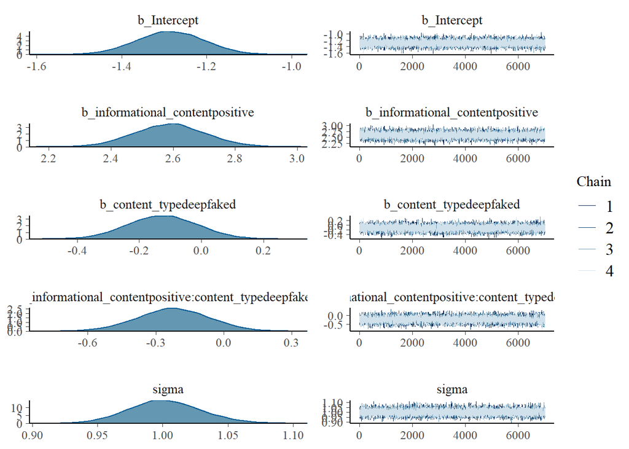

```r
plot(fit_confirmatory_selfreport, ask = FALSE)
```

### Check informativeness of prior

Using Gelman’s (2019) simple heuristic: For each parameter, compare the posterior sd to the prior sd. If the posterior sd for any parameter is more than 0.1 times the prior sd, then note that the prior was informative.

```r
check_prior(fit_confirmatory_selfreport) %>%
  kable() %>%
  kable_styling(bootstrap_options = c("striped", "hover", "condensed"),
                full_width = FALSE)
```

| Parameter | Prior_Quality |
| --- | --- |
| b_Intercept | uninformative |
| b_informational_contentpositive | uninformative |
| b_content_typedeepfaked | uninformative |
| b_informational_contentpositive:content_typedeepfaked | uninformative |

### Interpret posteriors

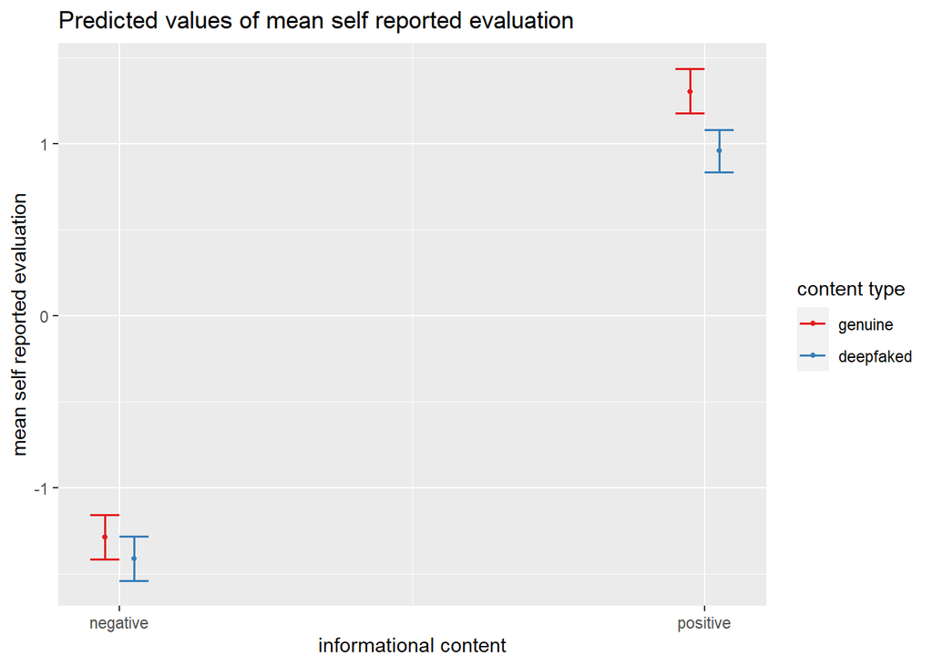

```r
# plot_model(fit_confirmatory_selfreport)
plot_model(fit_confirmatory_selfreport, type = "pred", terms = c("informational_content", "content_type"))
```

```r
# percent moderation
draws_sr <-
  bind_cols(
    select(spread_draws(fit_confirmatory_selfreport, b_informational_contentpositive), b_informational_contentpositive),
    select(spread_draws(fit_confirmatory_selfreport, b_content_typedeepfaked), b_content_typedeepfaked),
    select(spread_draws(fit_confirmatory_selfreport, `b_informational_contentpositive:content_typedeepfaked`), `b_informational_contentpositive:content_typedeepfaked`)
  ) %>%
  rename(main_valence = b_informational_contentpositive,
         main_content_type = b_content_typedeepfaked,
         interaction = `b_informational_contentpositive:content_typedeepfaked`) %>%
  mutate(effect_genuine = main_valence,
         effect_deepfaked = main_valence + interaction,
         #percent_moderation = (main_content_type + interaction)/main_valence *100,  # alt method, same result
         percent_comparison = (effect_deepfaked/effect_genuine)*100)

# results
estimates_sr <-
  map_estimate(draws_sr) %>%
  full_join(bayestestR::hdi(draws_sr, ci = .95) %>%
              rename(CI_95_lower = CI_low,
                     CI_95_upper = CI_high) %>%
              as_tibble(),
            by = "Parameter") %>%
  full_join(bayestestR::hdi(draws_sr, ci = .90) %>%
              as_tibble() %>%
              rename(CI_90_lower = CI_low,
                     CI_90_upper = CI_high),
            by = "Parameter") %>%
  full_join(draws_sr %>%
              select(-percent_comparison) %>%
              gather(Parameter, value) %>%
              group_by(Parameter) %>%
              summarize(pd = mean(value > 0)) %>%
              mutate(p = pd_to_p(pd, direction = "one-sided")) %>%
              ungroup() %>%
              select(Parameter, p),
            by = "Parameter") %>%
  select(Parameter, MAP_Estimate, CI_95_lower, CI_95_upper,
         CI_90_lower, CI_90_upper, p)

# results table
estimates_sr %>%
  mutate_at(.vars = c("MAP_Estimate", "CI_95_lower", "CI_95_upper", "CI_90_lower", "CI_90_upper"), round, digits = 2) %>%
  # rename the variables here so that they are consistent with the naming conventions in the paper

  mutate(Parameter = replace(Parameter, Parameter == "main_valence", "main_effect_information_content")) %>%
  mutate(Parameter = replace(Parameter, Parameter == "main_content_type", "main_effect_content_type")) %>%

  kable() %>%
  kable_styling(bootstrap_options = c("striped", "hover", "condensed"),
                full_width = FALSE)
```

| Parameter | MAP_Estimate | CI_95_lower | CI_95_upper | CI_90_lower | CI_90_upper | p |
| --- | --- | --- | --- | --- | --- | --- |
| main_effect_information_content | 2.60 | 2.37 | 2.81 | 2.40 | 2.77 | 0.0000000 |
| main_effect_content_type | -0.11 | -0.34 | 0.09 | -0.31 | 0.06 | 0.1350357 |
| interaction | -0.23 | -0.54 | 0.08 | -0.48 | 0.04 | 0.0795000 |
| effect_genuine | 2.60 | 2.37 | 2.81 | 2.40 | 2.77 | 0.0000000 |
| effect_deepfaked | 2.38 | 2.15 | 2.58 | 2.19 | 2.55 | 0.0000000 |
| percent_comparison | 91.11 | 80.24 | 103.08 | 81.91 | 101.10 | / |

```r
# hypothesis testing
H1a <- ifelse((estimates_sr %>% filter(Parameter == "effect_genuine") %>% pull(CI_95_lower)) > 0,
              "Accepted", "Rejected")

H1b <- ifelse((estimates_sr %>% filter(Parameter == "effect_deepfaked") %>% pull(CI_95_lower)) > 0,
              "Accepted", "Rejected")

H2a <- ifelse((estimates_sr %>% filter(Parameter == "effect_deepfaked") %>% pull(CI_90_lower)) >
                (estimates_sr %>% filter(Parameter == "effect_genuine") %>% pull(CI_95_lower)),
              "Accepted", "Rejected")

comparison_string_sr <-
  paste0("Deepfakes are ",
         estimates_sr %>% filter(Parameter == "percent_comparison") %>% pull(MAP_Estimate) %>% round(1),
         "% (95% CI [",
         estimates_sr %>% filter(Parameter == "percent_comparison") %>% pull(CI_95_lower) %>% round(1),
         ", ",
         estimates_sr %>% filter(Parameter == "percent_comparison") %>% pull(CI_95_upper) %>% round(1),
         "]) as effective as genuine content in establishing self-reported evaluations")
```

*H1a*

The informational content of the genuine videos (i.e., positive vs. negative) will influence participants’ self-reported evaluations.

- Result: Accepted

*H1b*

The informational content of the Deepfaked videos (i.e., positive vs. negative) will influence participants’ self-reported evaluations.

- Result: Accepted

*H2a*

Change in self-reported evaluations (i.e., between informational content conditions) induced by Deepfaked video content will be non-inferior to genuine content.

- Result: Rejected. Deepfakes are 91.1% (95% CI [80.2, 103.1]) as effective as genuine content in establishing self-reported evaluations.

## Implicit

### Fit model

```r
fit_confirmatory_implicit <-
  brm(formula = IAT_D2 ~ informational_content * content_type,
      family = gaussian(),
      data    = data_after_exclusions,
      file    = "models/fit_confirmatory_implicit",
      prior   = prior(normal(0, 10)),
      iter    = 10000,
      warmup  = 3000,
      control = list(adapt_delta = 0.99),  # to avoid divergent transitions
      chains  = 4,
      cores   = parallel::detectCores())
```

### Inspect convergence

```r
summary(fit_confirmatory_implicit)
```

```
##  Family: gaussian
##   Links: mu = identity; sigma = identity
## Formula: IAT_D2 ~ informational_content * content_type
##    Data: data_after_exclusions (Number of observations: 635)
##   Draws: 4 chains, each with iter = 10000; warmup = 3000; thin = 1;
##          total post-warmup draws = 28000
##
## Population-Level Effects:
##                                                     Estimate Est.Error l-95% CI
## Intercept                                              -0.04      0.08    -0.20
## informational_contentpositive                           1.39      0.11     1.16
## content_typedeepfaked                                   0.17      0.11    -0.05
## informational_contentpositive:content_typedeepfaked    -0.04      0.16    -0.36
##                                                     u-95% CI Rhat Bulk_ESS
## Intercept                                               0.11 1.00    13812
## informational_contentpositive                           1.61 1.00    12266
## content_typedeepfaked                                   0.39 1.00    11977
## informational_contentpositive:content_typedeepfaked     0.27 1.00    10466
##                                                     Tail_ESS
## Intercept                                              17606
## informational_contentpositive                          15767
## content_typedeepfaked                                  15424
## informational_contentpositive:content_typedeepfaked    14533
##
## Family Specific Parameters:
##       Estimate Est.Error l-95% CI u-95% CI Rhat Bulk_ESS Tail_ESS
## sigma     1.00      0.03     0.95     1.06 1.00    19474    17477
##
## Draws were sampled using sampling(NUTS). For each parameter, Bulk_ESS
## and Tail_ESS are effective sample size measures, and Rhat is the potential
## scale reduction factor on split chains (at convergence, Rhat = 1).
```

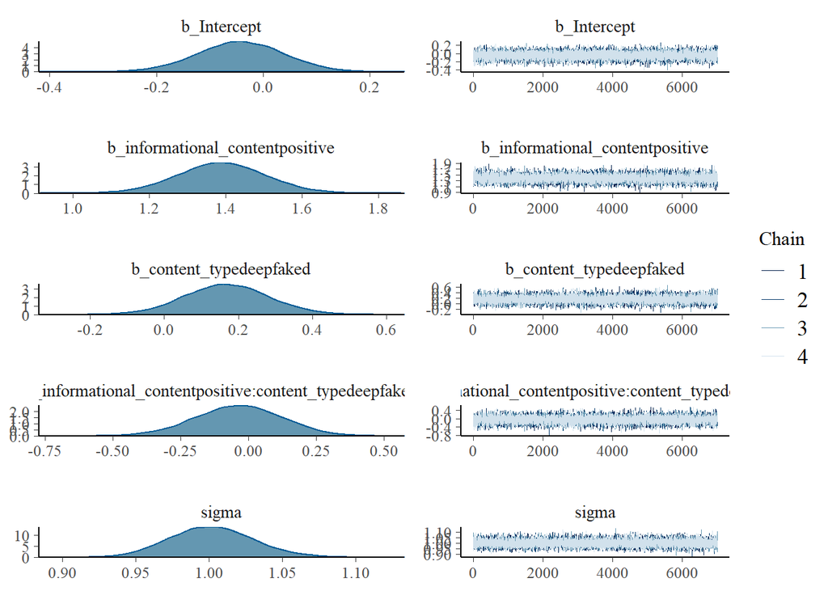

```r
plot(fit_confirmatory_implicit, ask = FALSE)
```

### Check informativeness of prior

Using Gelman’s (2019) simple heuristic: For each parameter, compare the posterior sd to the prior sd. If the posterior sd for any parameter is more than 0.1 times the prior sd, then note that the prior was informative.

```r
check_prior(fit_confirmatory_implicit) %>%

    mutate(Parameter = replace(Parameter, Parameter == "b_source_valencepositive", "b_information_content"),
         Parameter = replace(Parameter, Parameter == "b_experiment_conditiondeepfaked", "b_content_type_deepfaked"),
         Parameter = replace(Parameter, Parameter == "b_source_valencepositive:experiment_conditiondeepfaked", "b_information_content:content_type_deepfaked")) %>%


  kable() %>%
  kable_styling(bootstrap_options = c("striped", "hover", "condensed"),
                full_width = FALSE)
```

| Parameter | Prior_Quality |
| --- | --- |
| b_Intercept | uninformative |
| b_informational_contentpositive | uninformative |
| b_content_typedeepfaked | uninformative |
| b_informational_contentpositive:content_typedeepfaked | uninformative |

### Interpret posteriors

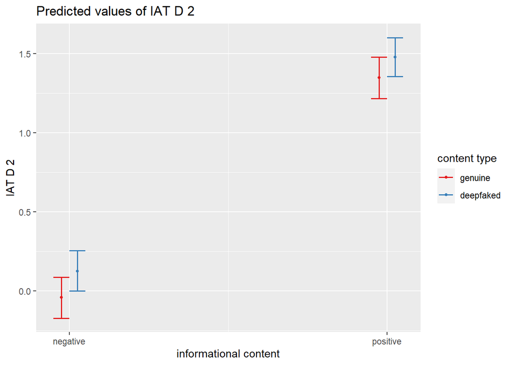

```r
#plot_model(fit_confirmatory_implicit)
plot_model(fit_confirmatory_implicit, type = "pred", terms = c("informational_content", "content_type"))
```

```r
# percent moderation
draws_imp <-
  bind_cols(
    select(spread_draws(fit_confirmatory_implicit, b_informational_contentpositive), b_informational_contentpositive),
    select(spread_draws(fit_confirmatory_implicit, b_content_typedeepfaked), b_content_typedeepfaked),
    select(spread_draws(fit_confirmatory_implicit, `b_informational_contentpositive:content_typedeepfaked`), `b_informational_contentpositive:content_typedeepfaked`)
  ) %>%
  rename(main_valence = b_informational_contentpositive,
         main_experiment_condition = b_content_typedeepfaked,
         interaction = `b_informational_contentpositive:content_typedeepfaked`) %>%
  mutate(effect_genuine = main_valence,
         effect_deepfaked = main_valence + interaction,
         #percent_moderation = (main_experiment_condition + interaction)/main_valence *100,  # alt method, same result
         percent_comparison = (effect_deepfaked/effect_genuine)*100)

# results table
estimates_imp <-
  map_estimate(draws_imp) %>%
  full_join(bayestestR::hdi(draws_imp, ci = .95) %>%
              rename(CI_95_lower = CI_low,
                     CI_95_upper = CI_high) %>%
              as_tibble(),
            by = "Parameter") %>%
  full_join(bayestestR::hdi(draws_imp, ci = .90) %>%
              as_tibble() %>%
              rename(CI_90_lower = CI_low,
                     CI_90_upper = CI_high),
            by = "Parameter") %>%
  full_join(draws_imp %>%
              select(-percent_comparison) %>%
              gather(Parameter, value) %>%
              group_by(Parameter) %>%
              summarize(pd = mean(value > 0)) %>%
              mutate(p = pd_to_p(pd, direction = "one-sided")) %>%
              ungroup() %>%
              select(Parameter, p),
            by = "Parameter") %>%
  select(Parameter, MAP_Estimate, CI_95_lower, CI_95_upper,
         CI_90_lower, CI_90_upper, p)

estimates_imp %>%
  mutate_at(.vars = c("MAP_Estimate", "CI_95_lower", "CI_95_upper", "CI_90_lower", "CI_90_upper"), round, digits = 2) %>%

  # rename the variables here so that they are consistent with the naming conventions in the paper

  mutate(Parameter = replace(Parameter, Parameter == "main_valence", "main_effect_information_content")) %>%
  mutate(Parameter = replace(Parameter, Parameter == "main_experiment_condition", "main_effect_content_type")) %>%


  kable() %>%
  kable_styling(bootstrap_options = c("striped", "hover", "condensed"),
                full_width = FALSE)
```

| Parameter | MAP_Estimate | CI_95_lower | CI_95_upper | CI_90_lower | CI_90_upper | p |
| --- | --- | --- | --- | --- | --- | --- |
| main_effect_information_content | 1.38 | 1.16 | 1.61 | 1.20 | 1.58 | 0.0000000 |
| main_effect_content_type | 0.16 | -0.06 | 0.39 | -0.02 | 0.35 | 0.0678929 |
| interaction | -0.03 | -0.35 | 0.28 | -0.30 | 0.23 | 0.4132143 |
| effect_genuine | 1.38 | 1.16 | 1.61 | 1.20 | 1.58 | 0.0000000 |
| effect_deepfaked | 1.37 | 1.14 | 1.57 | 1.17 | 1.53 | 0.0000000 |
| percent_comparison | 96.93 | 75.87 | 120.87 | 79.07 | 116.85 | / |

```r
# hypothesis testing
H1c <- ifelse((estimates_imp %>% filter(Parameter == "effect_genuine") %>% pull(CI_95_lower)) > 0,
              "Accepted", "Rejected")

H1d <- ifelse((estimates_imp %>% filter(Parameter == "effect_deepfaked") %>% pull(CI_95_lower)) > 0,
              "Accepted", "Rejected")

H2b <- ifelse((estimates_imp %>% filter(Parameter == "effect_deepfaked") %>% pull(CI_90_lower)) >
                (estimates_imp %>% filter(Parameter == "effect_genuine") %>% pull(CI_95_lower)),
              "Accepted", "Rejected")

comparison_string_imp <-
  paste0("Deepfakes are ",
         estimates_imp %>% filter(Parameter == "percent_comparison") %>% pull(MAP_Estimate) %>% round(1),
         "% (95% CI [",
         estimates_imp %>% filter(Parameter == "percent_comparison") %>% pull(CI_95_lower) %>% round(1),
         ", ",
         estimates_imp %>% filter(Parameter == "percent_comparison") %>% pull(CI_95_upper) %>% round(1),
         "]) as effective as genuine content in establishing self-reported evaluations")
```

*H1c*

The informational content of the genuine videos (i.e., positive vs. negative) will influence participants’ IAT D2 scores.

- Result: Accepted

*H1d*

The informational content of the Deepfaked videos (i.e., positive vs. negative) will influence participants’ IAT D2 scores.

- Result: Accepted

*H2b*

Change in IAT D2 scores (i.e., between informational content conditions) induced by Deepfaked video content will be non-inferior to those induced by genuine videos.

- Result: Accepted. Deepfakes are 96.9% (95% CI [75.9, 120.9]) as effective as genuine content in establishing self-reported evaluations.

## Behavioural intentions

### Fit model

```r
fit_confirmatory_intentions <-
  brm(formula = mean_intentions ~ informational_content * content_type,
      family = gaussian(),
      data    = data_after_exclusions,
      file    = "models/fit_confirmatory_intentions",
      prior   = prior(normal(0, 10)),
      iter    = 10000,
      warmup  = 3000,
      control = list(adapt_delta = 0.99),  # to avoid divergent transitions
      chains  = 4,
      cores   = parallel::detectCores())
```

### Inspect convergence

```r
summary(fit_confirmatory_intentions)
```

```
##  Family: gaussian
##   Links: mu = identity; sigma = identity
## Formula: mean_intentions ~ informational_content * content_type
##    Data: data_after_exclusions (Number of observations: 635)
##   Draws: 4 chains, each with iter = 10000; warmup = 3000; thin = 1;
##          total post-warmup draws = 28000
##
## Population-Level Effects:
##                                                     Estimate Est.Error l-95% CI
## Intercept                                              -2.08      0.08    -2.24
## informational_contentpositive                           1.72      0.12     1.50
## content_typedeepfaked                                  -0.26      0.11    -0.48
## informational_contentpositive:content_typedeepfaked    -0.03      0.16    -0.34
##                                                     u-95% CI Rhat Bulk_ESS
## Intercept                                              -1.92 1.00    14632
## informational_contentpositive                           1.95 1.00    12568
## content_typedeepfaked                                  -0.03 1.00    13189
## informational_contentpositive:content_typedeepfaked     0.28 1.00    11462
##                                                     Tail_ESS
## Intercept                                              17489
## informational_contentpositive                          15688
## content_typedeepfaked                                  16317
## informational_contentpositive:content_typedeepfaked    14126
##
## Family Specific Parameters:
##       Estimate Est.Error l-95% CI u-95% CI Rhat Bulk_ESS Tail_ESS
## sigma     1.00      0.03     0.95     1.06 1.00    19190    17624
##
## Draws were sampled using sampling(NUTS). For each parameter, Bulk_ESS
## and Tail_ESS are effective sample size measures, and Rhat is the potential
## scale reduction factor on split chains (at convergence, Rhat = 1).
```

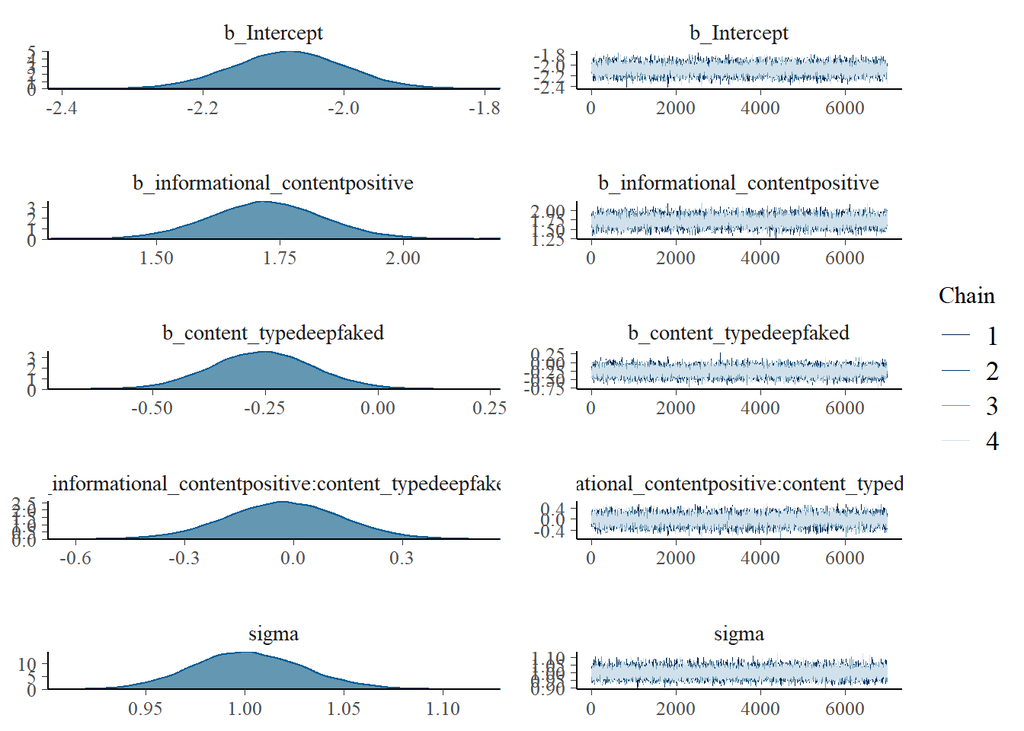

```r
plot(fit_confirmatory_intentions, ask = FALSE)
```

### Check informativeness of prior

Using Gelman’s (2019) simple heuristic: For each parameter, compare the posterior sd to the prior sd. If the posterior sd for any parameter is more than 0.1 times the prior sd, then note that the prior was informative.

```r
check_prior(fit_confirmatory_intentions) %>%
  # rename the variables here so that they are consistent with the naming conventions in the paper

    mutate(Parameter = replace(Parameter, Parameter == "b_source_valencepositive", "b_information_content"),
         Parameter = replace(Parameter, Parameter == "b_experiment_conditiondeepfaked", "b_content_type_deepfaked"),
         Parameter = replace(Parameter, Parameter == "b_source_valencepositive:experiment_conditiondeepfaked", "b_information_content:content_type_deepfaked")) %>%

  kable() %>%
  kable_styling(bootstrap_options = c("striped", "hover", "condensed"),
                full_width = FALSE)
```

| Parameter | Prior_Quality |
| --- | --- |
| b_Intercept | uninformative |
| b_informational_contentpositive | uninformative |
| b_content_typedeepfaked | uninformative |
| b_informational_contentpositive:content_typedeepfaked | uninformative |

informational_content * content_type

### Interpret posteriors

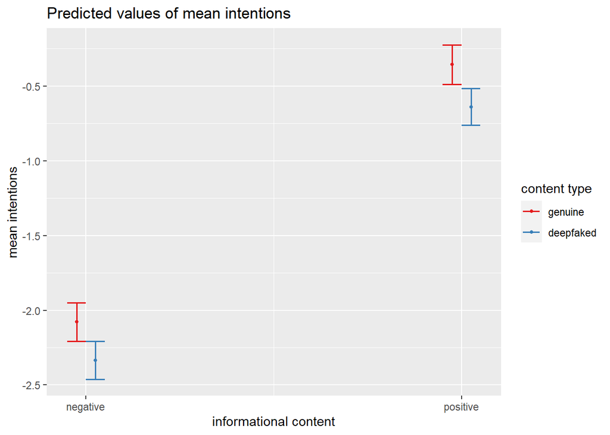

```r
#plot_model(fit_confirmatory_intentions)
plot_model(fit_confirmatory_intentions, type = "pred", terms = c("informational_content", "content_type"))
```

```r
# percent moderation
draws_intentions <-
  bind_cols(
    select(spread_draws(fit_confirmatory_intentions, b_informational_contentpositive), b_informational_contentpositive),
    select(spread_draws(fit_confirmatory_intentions, b_content_typedeepfaked), b_content_typedeepfaked),
    select(spread_draws(fit_confirmatory_intentions, `b_informational_contentpositive:content_typedeepfaked`), `b_informational_contentpositive:content_typedeepfaked`)
  ) %>%
  rename(main_informational_content = b_informational_contentpositive,
         main_content_type = b_content_typedeepfaked,
         interaction = `b_informational_contentpositive:content_typedeepfaked`) %>%
  mutate(effect_genuine = main_informational_content,
         effect_deepfaked = main_informational_content + interaction,
         #percent_moderation = (main_content_type + interaction)/main_informational_content *100,  # alt method, same result
         percent_comparison = (effect_deepfaked/effect_genuine)*100)

# results table
estimates_intentions <-
  map_estimate(draws_intentions) %>%
  full_join(bayestestR::hdi(draws_intentions, ci = .95) %>%
              rename(CI_95_lower = CI_low,
                     CI_95_upper = CI_high) %>%
              as_tibble(),
            by = "Parameter") %>%
  full_join(bayestestR::hdi(draws_intentions, ci = .90) %>%
              as_tibble() %>%
              rename(CI_90_lower = CI_low,
                     CI_90_upper = CI_high),
            by = "Parameter") %>%
  full_join(draws_intentions %>%
              select(-percent_comparison) %>%
              gather(Parameter, value) %>%
              group_by(Parameter) %>%
              summarize(pd = mean(value > 0)) %>%
              mutate(p = pd_to_p(pd, direction = "one-sided")) %>%
              ungroup() %>%
              select(Parameter, p),
            by = "Parameter") %>%
  select(Parameter, MAP_Estimate, CI_95_lower, CI_95_upper,
         CI_90_lower, CI_90_upper, p)

estimates_intentions %>%
  mutate_at(.vars = c("MAP_Estimate", "CI_95_lower", "CI_95_upper", "CI_90_lower", "CI_90_upper"), round, digits = 2) %>%

  # rename the variables here so that they are consistent with the naming conventions in the paper

  mutate(Parameter = replace(Parameter, Parameter == "main_valence", "main_effect_information_content")) %>%
  mutate(Parameter = replace(Parameter, Parameter == "main_experiment_condition", "main_effect_content_type")) %>%


  kable() %>%
  kable_styling(bootstrap_options = c("striped", "hover", "condensed"),
                full_width = FALSE)
```

| Parameter | MAP_Estimate | CI_95_lower | CI_95_upper | CI_90_lower | CI_90_upper | p |
| --- | --- | --- | --- | --- | --- | --- |
| main_informational_content | 1.72 | 1.50 | 1.95 | 1.54 | 1.91 | 0.0000000 |
| main_content_type | -0.25 | -0.48 | -0.04 | -0.45 | -0.08 | 0.0118929 |
| interaction | -0.03 | -0.34 | 0.29 | -0.29 | 0.24 | 0.4308571 |
| effect_genuine | 1.72 | 1.50 | 1.95 | 1.54 | 1.91 | 0.0000000 |
| effect_deepfaked | 1.69 | 1.49 | 1.92 | 1.52 | 1.87 | 0.0000000 |
| percent_comparison | 97.89 | 80.45 | 116.83 | 84.12 | 114.35 | / |

```r
# hypothesis testing
H1e <- ifelse((estimates_intentions %>% filter(Parameter == "effect_genuine") %>% pull(CI_95_lower)) > 0,
              "Accepted", "Rejected")

H1f <- ifelse((estimates_intentions %>% filter(Parameter == "effect_deepfaked") %>% pull(CI_95_lower)) > 0,
              "Accepted", "Rejected")

H2c <- ifelse((estimates_intentions %>% filter(Parameter == "effect_deepfaked") %>% pull(CI_90_lower)) >
                (estimates_intentions %>% filter(Parameter == "effect_genuine") %>% pull(CI_95_lower)),
              "Accepted", "Rejected")

comparison_string_intentions <-
  paste0("Deepfakes are ",
         estimates_intentions %>% filter(Parameter == "percent_comparison") %>% pull(MAP_Estimate) %>% round(1),
         "% (95% CI [",
         estimates_intentions %>% filter(Parameter == "percent_comparison") %>% pull(CI_95_lower) %>% round(1),
         ", ",
         estimates_intentions %>% filter(Parameter == "percent_comparison") %>% pull(CI_95_upper) %>% round(1),
         "]) as effective as genuine content in establishing self-reported evaluations")
```

*H1e*

The informational content of the genuine videos (i.e., positive vs. negative) will influence participants’ behavioral intention responses.

- Result: Accepted

*H1f*

The informational content of the Deepfaked videos (i.e., positive vs. negative) will influence participants’ behavioral intention responses.

- Result: Accepted

*H2c*

Change in behavioral intentions (i.e., between informational content conditions) induced by Deepfaked video content will be non-inferior to genuine content.

- Result: Accepted. Deepfakes are 97.9% (95% CI [80.5, 116.8]) as effective as genuine content in establishing self-reported evaluations.

# RQ3: How good are people at detecting Deepfakes?

## Can people accurately detect deepfakes?

- Youden’s J = sensitivity + specificity - 1, aka informedness, aka “the probability of an informed decision (as opposed to a random guess) and takes into account all predictions”
- 95% CIs were bootstrapped via case removal and the percentile method.

### Sample size

```r
data_after_exclusions %>%
  count(content_type,
        deepfake_detection_closed) %>%
  drop_na() %>%
  kable() %>%
  kable_styling(bootstrap_options = c("striped", "hover", "condensed"),
                full_width = FALSE)
```

| content_type | deepfake_detection_closed | n |
| --- | --- | --- |
| genuine | genuine | 184 |
| genuine | deepfaked | 120 |
| deepfaked | genuine | 109 |
| deepfaked | deepfaked | 221 |

### Classification stats

```r
data_classifications <- data_after_exclusions %>%
  select(content_type, deepfake_detection_closed) %>%
  drop_na()

truth <- factor(data_classifications$content_type,
                levels = rev(c("genuine", "deepfaked")))

pred <- factor(data_classifications$deepfake_detection_closed,
               levels = rev(c("genuine", "deepfaked")))

cm <- confusionMatrix(table(pred, truth))

fit_confirmatory_classification <-
  as_tibble(cm$byClass, rownames = "parameter") %>%
  spread(parameter, value) %>%
  mutate(balanced_accuracy = `Balanced Accuracy`,
         false_negative_rate = 1 - Sensitivity,
         false_positive_rate = 1 - Specificity,
         informedness = Sensitivity + Specificity - 1) %>%
  select(balanced_accuracy,
         informedness,
         false_negative_rate,
         false_positive_rate) %>%
  gather(variable, observed, c(balanced_accuracy,
                               informedness,
                               false_negative_rate,
                               false_positive_rate))
```

### Bootstrapped classification stats

```r
# create bootstraps using out of bag method. makes a df with values that are collapsed dfs.
boots <- data_classifications %>%
  bootstraps(times = 2000)

# function to bootstrap classification stats and return a tibble
bootstrap_categorization_stats <- function(split) {

  truth <- factor(analysis(split)$content_type,
                  levels = rev(c("genuine", "deepfaked")))

  pred <- factor(analysis(split)$deepfake_detection_closed,
                 levels = rev(c("genuine", "deepfaked")))

  cm <- confusionMatrix(table(pred, truth))

  results <-
    as_tibble(cm$byClass, rownames = "parameter") %>%
    spread(parameter, value) %>%
    mutate(balanced_accuracy = `Balanced Accuracy`,
           false_negative_rate = 1 - Sensitivity,
           false_positive_rate = 1 - Specificity,
           informedness = Sensitivity + Specificity - 1) %>%
    select(balanced_accuracy,
           informedness,
           false_negative_rate,
           false_positive_rate)

  return(results)
}

# apply to each bootstrap
fit_confirmatory_classification_bootstraps <- boots %>%
  mutate(categorization_stats = future_map(splits, bootstrap_categorization_stats)) %>%
  select(-splits) %>%
  unnest(categorization_stats)
```

### Results

```r
classifications <- fit_confirmatory_classification_bootstraps %>%
  gather(variable, value, c(balanced_accuracy,
                            informedness,
                            false_negative_rate,
                            false_positive_rate)) %>%
  group_by(variable) %>%
  summarize(ci_lower = quantile(value, 0.025),
            ci_upper = quantile(value, 0.975),
            .groups  = "drop") %>%
  full_join(fit_confirmatory_classification, by = "variable") %>%
  mutate_if(is.numeric, round, digits = 2) %>%
  select(variable, observed, ci_lower, ci_upper)

classifications %>%
  kable() %>%
  kable_styling(bootstrap_options = c("striped", "hover", "condensed"),
                full_width = FALSE)
```

| variable | observed | ci_lower | ci_upper |
| --- | --- | --- | --- |
| balanced_accuracy | 0.64 | 0.60 | 0.67 |
| false_negative_rate | 0.33 | 0.28 | 0.38 |
| false_positive_rate | 0.39 | 0.34 | 0.45 |
| informedness | 0.27 | 0.20 | 0.35 |

H3: Participants are poor at making accurate and informed judgements about whether online video content is genuine or Deepfaked. Our predictions here are descriptive/continuous rather than involving cut-off based inference rules.

- H3a. We expect a substantial proportion of participants to be poor at correctly detecting Deepfakes. This will be examined using the false negative rate, although we do not have numerical predictions here.
- H3b. We expect a substantial proportion of participants to incorrectly detect Deepfakes even when the video content was real/.This will be examined using the false positive rate, although we do not have numerical predictions here.
- H3c. We expect participants to be poor at making accurate decisions about whether content is genuine or not (e.g., Balanced Accuracy not greatly above chance, circa .60), far less than what might be considered highly accurate decisions (e.g., BA of .80 or .90).
- H3d. We expect participants to make poorly informed decisions about whether content is genuine or not, (e.g., informedness/Youden’s J of circa .20), far less than what might be considered highly informed decisions (e.g., J of .80 or .90).

## Even the subset of participants who were aware of the concept of Deepfakes before the study?

Same descriptive predictions as above.

### Sample size

```r
data_after_exclusions %>%
  filter(deepfake_awareness_closed == "aware") %>%
  count(content_type,
        deepfake_detection_closed) %>%
  drop_na() %>%
  kable() %>%
  kable_styling(bootstrap_options = c("striped", "hover", "condensed"),
                full_width = FALSE)
```

| content_type | deepfake_detection_closed | n |
| --- | --- | --- |
| genuine | genuine | 100 |
| genuine | deepfaked | 62 |
| deepfaked | genuine | 50 |
| deepfaked | deepfaked | 145 |

### Classification stats

```r
data_classifications_subset <- data_after_exclusions %>%
  filter(deepfake_awareness_closed == "aware") %>%
  select(content_type, deepfake_detection_closed) %>%
  drop_na()

truth_subset <- factor(data_classifications_subset$content_type,
                levels = rev(c("genuine", "deepfaked")))

pred_subset <- factor(data_classifications_subset$deepfake_detection_closed,
               levels = rev(c("genuine", "deepfaked")))

cm_subset <- confusionMatrix(table(pred_subset, truth_subset))

fit_confirmatory_classification_subset <-
  as_tibble(cm_subset$byClass, rownames = "parameter") %>%
  spread(parameter, value) %>%
  mutate(balanced_accuracy = `Balanced Accuracy`,
         false_negative_rate = 1 - Sensitivity,
         false_positive_rate = 1 - Specificity,
         informedness = Sensitivity + Specificity - 1) %>%
  select(balanced_accuracy,
         informedness,
         false_negative_rate,
         false_positive_rate) %>%
  gather(variable, observed, c(balanced_accuracy,
                               informedness,
                               false_negative_rate,
                               false_positive_rate))
```

### Bootstrapped classification stats

```r
# create bootstraps using out of bag method. makes a df with values that are collapsed dfs.
boots_subset <- data_classifications_subset %>%
  bootstraps(times = 2000)

# apply to each bootstrap
fit_confirmatory_classification_bootstraps_subset <- boots_subset %>%
  mutate(categorization_stats = future_map(splits, bootstrap_categorization_stats)) %>%
  select(-splits) %>%
  unnest(categorization_stats)
```

### Results

```r
classifications_subset <- fit_confirmatory_classification_bootstraps_subset %>%
  gather(variable, value, c(balanced_accuracy,
                            informedness,
                            false_negative_rate,
                            false_positive_rate)) %>%
  group_by(variable) %>%
  summarize(ci_lower = quantile(value, 0.025),
            ci_upper = quantile(value, 0.975),
            .groups  = "drop") %>%
  full_join(fit_confirmatory_classification_subset, by = "variable") %>%
  mutate_if(is.numeric, round, digits = 2) %>%
  select(variable, observed, ci_lower, ci_upper)

classifications_subset %>%
  kable() %>%
  kable_styling(bootstrap_options = c("striped", "hover", "condensed"),
                full_width = FALSE)
```

| variable | observed | ci_lower | ci_upper |
| --- | --- | --- | --- |
| balanced_accuracy | 0.68 | 0.63 | 0.73 |
| false_negative_rate | 0.26 | 0.20 | 0.32 |
| false_positive_rate | 0.38 | 0.31 | 0.46 |
| informedness | 0.36 | 0.26 | 0.45 |

# H4: Are people aware that content can be Deepfaked before they take part in the study, and does this make them better at detecting them?

## Percent of participants awareness of the concept prior to study

I.e., using the full sample and reporting the sample percentage.

Description of sample:

```r
percent_aware <- data_after_exclusions %>%
  dplyr::select(deepfake_awareness_closed) %>%
  drop_na() %>%
  count(deepfake_awareness_closed) %>%
  mutate(counts = n,
         awareness = as.factor(deepfake_awareness_closed),
         percent_aware = round(counts/sum(counts)*100, 1)) %>%
  filter(awareness == "aware") %>%
  dplyr::select(percent_aware)

percent_aware %>%
  kable() %>%
  kable_styling(bootstrap_options = c("striped", "hover", "condensed"),
                full_width = FALSE)
```

| percent_aware |
| --- |
| 56.3 |

## In the subset of participants who were shown a deepfake, did prior awareness make them more likely to detect it?

Putting aside true negatives and false positive, does prior awareness of the concept of deepfaking at least make people better at detecting deepfakes

It would of course be possible include data from both content_types and add it to the model, however interpreting the two and three way interactions is less intuitive. Given this question is of secondary importance, we therefore elected for the more simple analysis focusing on awareness and the FNR/TPR.

### Fit model

```r
# convert data to counts
data_counts_awareness_detection <- data_after_exclusions %>%
  filter(content_type == "deepfaked") %>%
  dplyr::select(experiment, deepfake_awareness_closed, deepfake_detection_closed) %>%
  drop_na() %>%
  mutate(deepfake_awareness_closed = case_when(deepfake_awareness_closed == "aware" ~ TRUE,
                                               deepfake_awareness_closed == "unaware" ~ FALSE),
         deepfake_detection_closed = case_when(deepfake_detection_closed == "deepfaked" ~ TRUE,
                                               deepfake_detection_closed == "genuine" ~ FALSE)) %>%
  count(experiment, deepfake_awareness_closed, deepfake_detection_closed) %>%
  group_by(experiment) %>%
  mutate(counts = n,
         awareness = as.factor(deepfake_awareness_closed),
         detection = as.factor(deepfake_detection_closed),
         proportion = counts/sum(counts)) %>%
  ungroup() %>%
  dplyr::select(experiment, awareness, detection, counts, proportion)

# total counts is needed later to convert to proportions
total_counts_awareness_detection <- data_counts_awareness_detection %>%
  group_by(experiment) %>%
  summarize(total = sum(counts)) %>%
  ungroup()

# fit poisson model
fit_confirmatory_poisson_awareness_detection <-
  brm(formula = counts ~ 1 + awareness * detection,
      family  = poisson(),
      data    = data_counts_awareness_detection,
      file    = "models/fit_confirmatory_poisson_awareness_detection",
      prior   = prior(normal(0, 10)),
      iter    = 10000,
      warmup  = 3000,
      control = list(adapt_delta = 0.998,
                     max_treedepth = 18),  # to avoid divergent transitions
      chains  = 4,
      cores   = parallel::detectCores())
```

### Inspect convergence

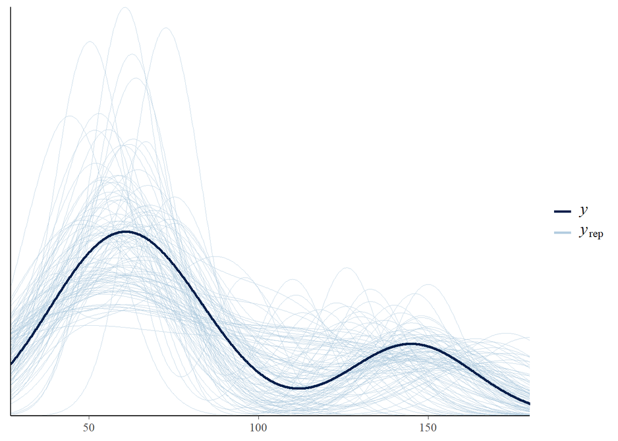

```r
pp_check(fit_confirmatory_poisson_awareness_detection, nsamples = 100)
```

```r
summary(fit_confirmatory_poisson_awareness_detection)
```

```
##  Family: poisson
##   Links: mu = log
## Formula: counts ~ 1 + awareness * detection
##    Data: data_counts_awareness_detection (Number of observations: 4)
##   Draws: 4 chains, each with iter = 10000; warmup = 3000; thin = 1;
##          total post-warmup draws = 28000
##
## Population-Level Effects:
##                             Estimate Est.Error l-95% CI u-95% CI Rhat Bulk_ESS
## Intercept                       4.07      0.13     3.81     4.31 1.00    11380
## awarenessTRUE                  -0.16      0.19    -0.54     0.21 1.00     9941
## detectionTRUE                   0.25      0.17    -0.08     0.59 1.00    10430
## awarenessTRUE:detectionTRUE     0.81      0.24     0.34     1.29 1.00     8928
##                             Tail_ESS
## Intercept                      14707
## awarenessTRUE                  13308
## detectionTRUE                  14537
## awarenessTRUE:detectionTRUE    11405
##
## Draws were sampled using sampling(NUTS). For each parameter, Bulk_ESS
## and Tail_ESS are effective sample size measures, and Rhat is the potential
## scale reduction factor on split chains (at convergence, Rhat = 1).
```

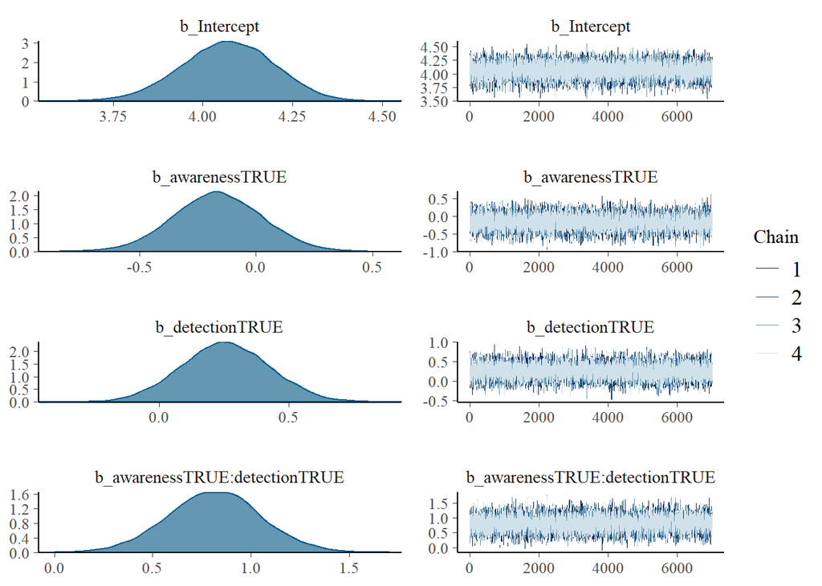

```r
plot(fit_confirmatory_poisson_awareness_detection, ask = FALSE)
```

### Check informativeness of prior

Using Gelman’s (2019) simple heuristic: For each parameter, compare the posterior sd to the prior sd. If the posterior sd for any parameter is more than 0.1 times the prior sd, then note that the prior was informative.

```r
check_prior(fit_confirmatory_poisson_awareness_detection) %>%
  kable() %>%
  kable_styling(bootstrap_options = c("striped", "hover", "condensed"),
                full_width = FALSE)
```

| Parameter | Prior_Quality |
| --- | --- |
| b_Intercept | uninformative |
| b_awarenessTRUE | uninformative |
| b_detectionTRUE | uninformative |
| b_awarenessTRUE:detectionTRUE | uninformative |

### Interpret posteriors

sjPlot doesn’t behave well with these variable names for some reason. From top to bottom, the parameters are awareness, detection, and awareness*detection.

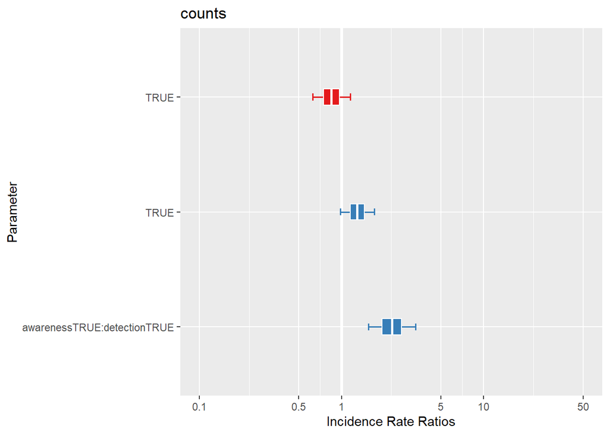

```r
plot_model(fit_confirmatory_poisson_awareness_detection) + xlab("Parameter")
```

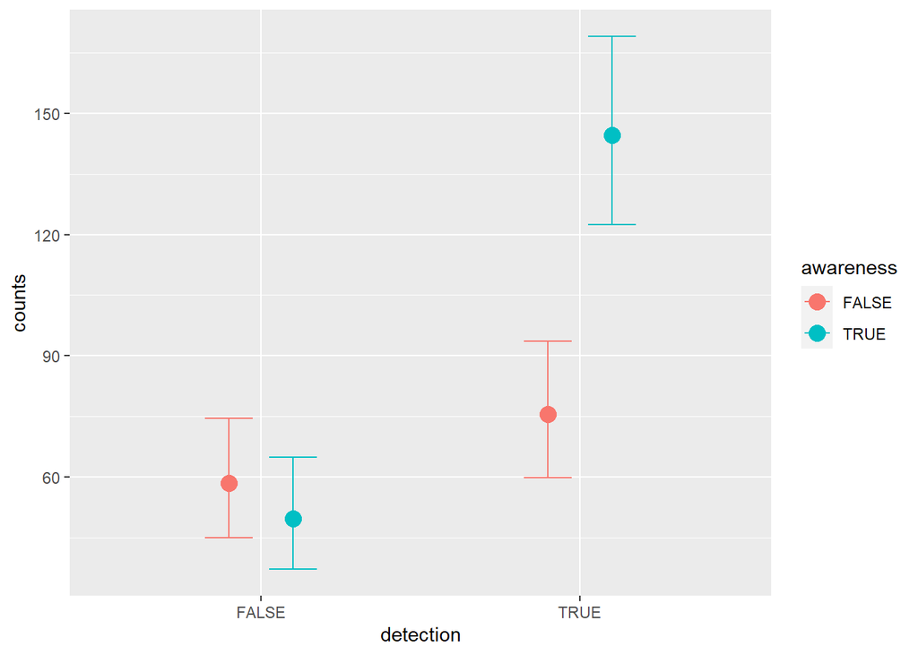

```r
plot(conditional_effects(fit_confirmatory_poisson_awareness_detection,
                         effects = "detection:awareness"), ask = FALSE)
```

#### Parameter estimates

```r
# posterior draws for parameters (for results table)
draws_awareness_detection <- posterior_samples(fit_confirmatory_poisson_awareness_detection) %>%
  dplyr::select(awarenessTRUE = b_awarenessTRUE,
                detectionTRUE = b_detectionTRUE,
                interaction   = `b_awarenessTRUE:detectionTRUE`) %>%
  mutate(effect_awareness_increases_detection = awarenessTRUE + interaction)

estimates_awareness_detection <-
  full_join(as_tibble(map_estimate(draws_awareness_detection)),
            as_tibble(bayestestR::hdi(draws_awareness_detection, ci = .95)),
          by = "Parameter") %>%
  # exponentiate the log IRR values to IRR
  mutate_if(is.numeric, exp) %>%
  full_join(draws_awareness_detection %>%
              gather(Parameter, value) %>%
              group_by(Parameter) %>%
              summarize(pd = mean(exp(value) > 1)) %>%
              mutate(p = pd_to_p(pd, direction = "one-sided")) %>%
              ungroup() %>%
              select(Parameter, p),
            by = "Parameter") %>%
  dplyr::select(Parameter, incidence_rate_ratio_MAP = MAP_Estimate, CI_95_lower = CI_low, CI_95_upper = CI_high, p)
  # convert from odds to probability
  # mutate_if(is.numeric, function(x){x/(1+x)})

# table
estimates_awareness_detection %>%
  mutate_at(vars("incidence_rate_ratio_MAP", "CI_95_lower", "CI_95_upper"), round, digits = 2) %>%
  kable() %>%
  kable_styling(bootstrap_options = c("striped", "hover", "condensed"),
                full_width = FALSE)
```

| Parameter | incidence_rate_ratio_MAP | CI_95_lower | CI_95_upper | p |
| --- | --- | --- | --- | --- |
| awarenessTRUE | 0.84 | 0.58 | 1.24 | 0.1952143 |
| detectionTRUE | 1.28 | 0.92 | 1.79 | 0.0680000 |
| interaction | 2.35 | 1.40 | 3.58 | 0.0001786 |
| effect_awareness_increases_detection | 1.92 | 1.45 | 2.51 | 0.0000000 |

```r
# hypothesis testing
H4 <- ifelse((estimates_awareness_detection %>% filter(Parameter == "effect_awareness_increases_detection") %>%
                pull(CI_95_lower)) > 1,
              "Accepted", "Rejected")

comparison_string_awareness_detection <-
  paste0("Individuals who were aware of the concept of Deepfakes prior to participating in the study were ",
         estimates_awareness_detection %>%
           filter(Parameter == "effect_awareness_increases_detection") %>%
           pull(incidence_rate_ratio_MAP) %>%
           round(1),
         " times more likely to detect that they had been shown a deepfake than those who were not aware of the concept (Incidence Rate Ratio = ",
         estimates_awareness_detection %>%
           filter(Parameter == "effect_awareness_increases_detection") %>%
           pull(incidence_rate_ratio_MAP) %>%
           round(2),
         ", 95% CI [",
         estimates_awareness_detection %>%
           filter(Parameter == "effect_awareness_increases_detection") %>%
           pull(CI_95_lower) %>%
           round(2),
         ", ",
         estimates_awareness_detection %>%
           filter(Parameter == "effect_awareness_increases_detection") %>%
           pull(CI_95_upper) %>%
           round(2),
         "])")
```

*H4: Are people aware that content can be Deepfaked before they take part in the study, and does this make them better at detecting them?*

Using the subset of participants who were in the Deepfake condition, we calculated counts for each of the combinations of the Deepfake concept check and Deepfake detection questions (e.g., awareness = TRUE & detection = TRUE, awareness = TRUE & detection = FALSE, etc.).

We then use a Bayesian Poisson model to estimate a 95% Credible Interval around the effect’s Incidence Rate Ratio. A Credible Interval whose lower bound is > 1 will be considered evidence in support of this hypothesis. Estimated marginal predicted probabilities will also be reported.

- Result: Accepted
- Individuals who were aware of the concept of Deepfakes prior to participating in the study were 1.9 times more likely to detect that they had been shown a deepfake than those who were not aware of the concept (Incidence Rate Ratio = 1.92, 95% CI [1.45, 2.51])

#### Predicted probabilities

```r
#posterior_predictions_awareness_detection <-
#  tibble(experiment = 5,
#          awareness = c("TRUE", "FALSE"),
#          detection = c("TRUE", "FALSE")) %>%
#   data_grid(experiment, awareness, detection) %>%
#   add_predicted_draws(model = fit_confirmatory_poisson_awareness_detection, re_formula = NULL) %>%
#   rename(predicted_count = .prediction) %>%
#   left_join(total_counts_awareness_detection, by = "experiment") %>%
#   mutate(predicted_probabiity = predicted_count/total) %>%
#   ungroup() %>%
#   dplyr::select(awareness, detection, predicted_count, predicted_probabiity)
#
#
# posterior_predictions_awareness_detection_aT_dT <- posterior_predictions_awareness_detection %>%
#   filter(awareness == "TRUE" & detection == "TRUE")
# posterior_predictions_awareness_detection_aT_dF <- posterior_predictions_awareness_detection %>%
#   filter(awareness == "TRUE" & detection == "FALSE")
# posterior_predictions_awareness_detection_aF_dT <- posterior_predictions_awareness_detection %>%
#   filter(awareness == "FALSE" & detection == "TRUE")
# posterior_predictions_awareness_detection_aF_dF <- posterior_predictions_awareness_detection %>%
#   filter(awareness == "FALSE" & detection == "FALSE")
#
#
# results_detection_probabilities <-
#   rbind(
#     bind_cols(as_tibble(map_estimate(posterior_predictions_awareness_detection_aT_dT$predicted_probabiity)),
#               as_tibble(bayestestR::hdi(posterior_predictions_awareness_detection_aT_dT$predicted_probabiity,
#                                         ci = .95))) %>%
#       mutate(awareness = "TRUE", detection = "TRUE"),
#     bind_cols(as_tibble(map_estimate(posterior_predictions_awareness_detection_aT_dF$predicted_probabiity)),
#               as_tibble(bayestestR::hdi(posterior_predictions_awareness_detection_aT_dF$predicted_probabiity,
#                                         ci = .95))) %>%
#       mutate(awareness = "TRUE", detection = "FALSE"),
#     bind_cols(as_tibble(map_estimate(posterior_predictions_awareness_detection_aF_dT$predicted_probabiity)),
#               as_tibble(bayestestR::hdi(posterior_predictions_awareness_detection_aF_dT$predicted_probabiity,
#                                         ci = .95))) %>%
#       mutate(awareness = "FALSE", detection = "TRUE"),
#     bind_cols(as_tibble(map_estimate(posterior_predictions_awareness_detection_aF_dF$predicted_probabiity)),
#               as_tibble(bayestestR::hdi(posterior_predictions_awareness_detection_aF_dF$predicted_probabiity,
#                                         ci = .95))) %>%
#       mutate(awareness = "FALSE", detection = "FALSE")
#   ) %>%
#   dplyr::select(awareness, detection, detection_probability_MAP = value,
#                 CI_95_lower = CI_low, CI_95_upper = CI_high) %>%
#   mutate_if(is.numeric, round, digits = 3)
#
# results_detection_probabilities %>%
#   kable() %>%
#   kable_styling(bootstrap_options = c("striped", "hover", "condensed"),
#                 full_width = FALSE)
```

# RQ5: Does prior awareness of the concept of Deepfakes make people immune to their influence?

Subset who received deepfaked videos and were aware of the concept prior to the experiment. Same Bayesian multilevel models as employed above, using only informational_content as IV, i.e., to detect whether learning effects are credibly non-zero in this subset.

## Sample sizes

```r
data_aware_subset_n <- data_after_exclusions %>%
  filter(content_type == "deepfaked" & deepfake_awareness_closed == "aware") %>%
  count(deepfake_awareness_closed) %>%
  mutate(proportion = round(n/sum(n), 2)) %>%
  arrange(desc(proportion))

data_aware_subset_n %>%
  kable() %>%
  kable_styling(bootstrap_options = c("striped", "hover", "condensed"),
                full_width = FALSE)
```

| deepfake_awareness_closed | n | proportion |
| --- | --- | --- |
| aware | 195 | 1 |

```r
data_aware_subset <- data_after_exclusions %>%
  filter(content_type == "deepfaked" & deepfake_awareness_closed == "aware")
```

## Self-reported evaluations

### Fit model

```r
fit_confirmatory_selfreport_deepfaked_aware <-
  brm(formula = mean_self_reported_evaluation ~ informational_content,
      family  = gaussian(),
      data    = data_aware_subset,
      file    = "models/fit_confirmatory_selfreport_deepfaked_aware",
      prior   = prior(normal(0, 10)),
      iter    = 10000,
      warmup  = 3000,
      control = list(adapt_delta = 0.99),  # to avoid divergent transitions
      chains  = 4,
      cores   = parallel::detectCores())
```

### Inspect convergence

```r
summary(fit_confirmatory_selfreport_deepfaked_aware)
```

```
##  Family: gaussian
##   Links: mu = identity; sigma = identity
## Formula: mean_self_reported_evaluation ~ informational_content
##    Data: data_aware_subset (Number of observations: 195)
##   Draws: 4 chains, each with iter = 10000; warmup = 3000; thin = 1;
##          total post-warmup draws = 28000
##
## Population-Level Effects:
##                               Estimate Est.Error l-95% CI u-95% CI Rhat
## Intercept                        -1.25      0.11    -1.46    -1.05 1.00
## informational_contentpositive     2.11      0.15     1.82     2.40 1.00
##                               Bulk_ESS Tail_ESS
## Intercept                        21695    16657
## informational_contentpositive    22318    17765
##
## Family Specific Parameters:
##       Estimate Est.Error l-95% CI u-95% CI Rhat Bulk_ESS Tail_ESS
## sigma     1.04      0.05     0.94     1.15 1.00    21751    17300
##
## Draws were sampled using sampling(NUTS). For each parameter, Bulk_ESS
## and Tail_ESS are effective sample size measures, and Rhat is the potential
## scale reduction factor on split chains (at convergence, Rhat = 1).
```

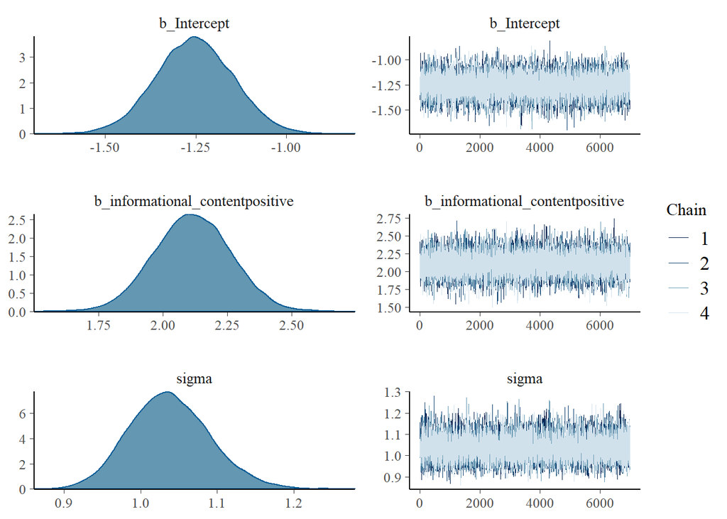

```r
plot(fit_confirmatory_selfreport_deepfaked_aware, ask = FALSE)
```

### Check informativeness of prior

Using Gelman’s (2019) simple heuristic: For each parameter, compare the posterior sd to the prior sd. If the posterior sd for any parameter is more than 0.1 times the prior sd, then note that the prior was informative.

```r
check_prior(fit_confirmatory_selfreport_deepfaked_aware) %>%
  kable() %>%
  kable_styling(bootstrap_options = c("striped", "hover", "condensed"),
                full_width = FALSE)
```

| Parameter | Prior_Quality |
| --- | --- |
| b_Intercept | uninformative |
| b_informational_contentpositive | uninformative |

### Interpret posteriors

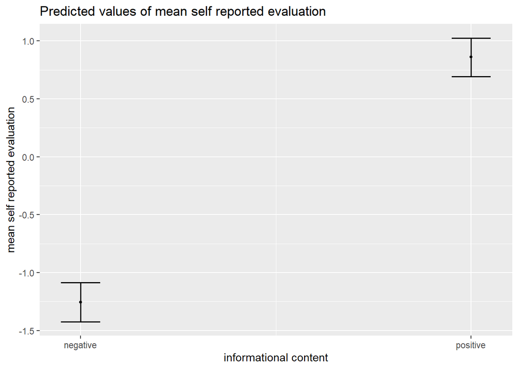

```r
#plot_model(fit_confirmatory_selfreport_deepfaked_aware)
plot_model(fit_confirmatory_selfreport_deepfaked_aware, type = "pred", terms = "informational_content")
```

```r
# results table
draws_sr_deepfaked_aware <-
  select(spread_draws(fit_confirmatory_selfreport_deepfaked_aware, b_informational_contentpositive), b_informational_contentpositive) %>%
  rename(effect_deepfaked_aware = b_informational_contentpositive)

estimates_sr_deepfaked_aware <-
  map_estimate(draws_sr_deepfaked_aware) %>%
  full_join(bayestestR::hdi(draws_sr_deepfaked_aware, ci = .95) %>%
              rename(CI_95_lower = CI_low,
                     CI_95_upper = CI_high) %>%
              as_tibble(),
            by = "Parameter") %>%
  full_join(bayestestR::hdi(draws_sr_deepfaked_aware, ci = .90) %>%
              as_tibble() %>%
              rename(CI_90_lower = CI_low,
                     CI_90_upper = CI_high),
            by = "Parameter") %>%
  full_join(draws_sr_deepfaked_aware %>%
              gather(Parameter, value) %>%
              group_by(Parameter) %>%
              summarize(pd = mean(value > 0)) %>%
              mutate(p = pd_to_p(pd, direction = "one-sided")) %>%
              ungroup() %>%
              select(Parameter, p),
            by = "Parameter") %>%
  select(Parameter, MAP_Estimate, CI_95_lower, CI_95_upper,
         CI_90_lower, CI_90_upper, p)

bind_rows(filter(estimates_sr, Parameter %in% c("effect_deepfaked")),
          estimates_sr_deepfaked_aware) %>%
  mutate_at(.vars = c("MAP_Estimate", "CI_95_lower", "CI_95_upper", "CI_90_lower", "CI_90_upper"), round, digits = 2) %>%
  kable() %>%
  kable_styling(bootstrap_options = c("striped", "hover", "condensed"),
                full_width = FALSE)
```

| Parameter | MAP_Estimate | CI_95_lower | CI_95_upper | CI_90_lower | CI_90_upper | p |
| --- | --- | --- | --- | --- | --- | --- |
| effect_deepfaked | 2.38 | 2.15 | 2.58 | 2.19 | 2.55 | 0 |
| effect_deepfaked_aware | 2.10 | 1.83 | 2.41 | 1.87 | 2.36 | 0 |

```r
# hypothesis testing
H5a <- ifelse((estimates_sr_deepfaked_aware %>% filter(Parameter == "effect_deepfaked_aware") %>%
                 pull(CI_95_lower)) > 0,
              "Accepted", "Rejected")
```

*H5a*

In the subset of participants who were shown a Deepfaked video and reported being aware of the concept of Deepfaking prior to participating in the experiment, the content of the Deepfaked videos (i.e., Source Valence) will influence participants’ self-reported evaluations.

- Result: Accepted

## Implicit

### Fit model

```r
fit_confirmatory_implicit_deepfaked_aware <-
  brm(formula = IAT_D2 ~ informational_content,
      family  = gaussian(),
      data    = data_aware_subset,
      file    = "models/fit_confirmatory_implicit_deepfaked_aware",
      prior   = prior(normal(0, 10)),
      iter    = 10000,
      warmup  = 3000,
      control = list(adapt_delta = 0.99),  # to avoid divergent transitions
      chains  = 4,
      cores   = parallel::detectCores())
```

### Inspect convergence

```r
summary(fit_confirmatory_implicit_deepfaked_aware)
```

```
##  Family: gaussian
##   Links: mu = identity; sigma = identity
## Formula: IAT_D2 ~ informational_content
##    Data: data_aware_subset (Number of observations: 195)
##   Draws: 4 chains, each with iter = 10000; warmup = 3000; thin = 1;
##          total post-warmup draws = 28000
##
## Population-Level Effects:
##                               Estimate Est.Error l-95% CI u-95% CI Rhat
## Intercept                         0.18      0.10    -0.03     0.38 1.00
## informational_contentpositive     1.31      0.14     1.03     1.59 1.00
##                               Bulk_ESS Tail_ESS
## Intercept                        20250    16967
## informational_contentpositive    20974    17102
##
## Family Specific Parameters:
##       Estimate Est.Error l-95% CI u-95% CI Rhat Bulk_ESS Tail_ESS
## sigma     1.01      0.05     0.91     1.11 1.00    21434    17169
##
## Draws were sampled using sampling(NUTS). For each parameter, Bulk_ESS
## and Tail_ESS are effective sample size measures, and Rhat is the potential
## scale reduction factor on split chains (at convergence, Rhat = 1).
```

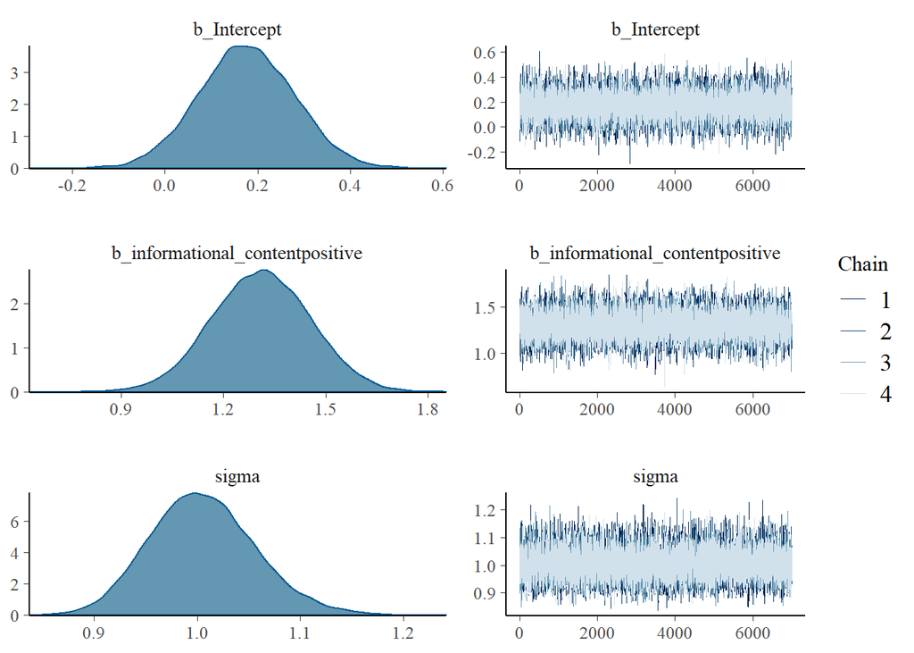

```r
plot(fit_confirmatory_implicit_deepfaked_aware, ask = FALSE)
```

### Check informativeness of prior

Using Gelman’s (2019) simple heuristic: For each parameter, compare the posterior sd to the prior sd. If the posterior sd for any parameter is more than 0.1 times the prior sd, then note that the prior was informative.

```r
check_prior(fit_confirmatory_implicit_deepfaked_aware) %>%
  kable() %>%
  kable_styling(bootstrap_options = c("striped", "hover", "condensed"),
                full_width = FALSE)
```

| Parameter | Prior_Quality |
| --- | --- |
| b_Intercept | uninformative |
| b_informational_contentpositive | uninformative |

### Interpret posteriors

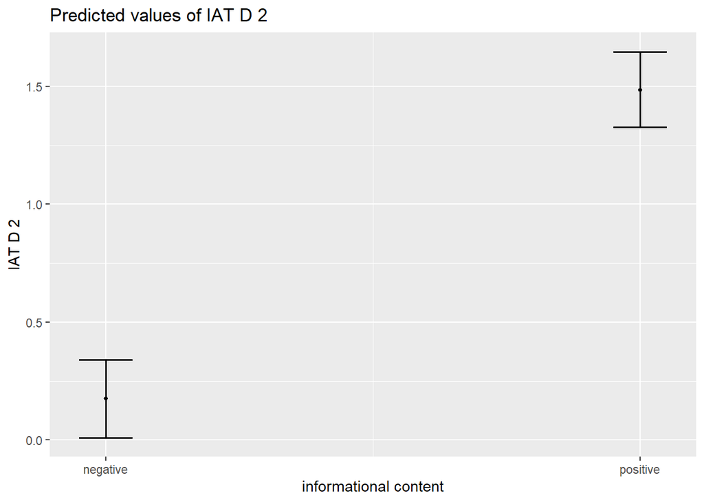

```r
#plot_model(fit_confirmatory_implicit_deepfaked_aware)
plot_model(fit_confirmatory_implicit_deepfaked_aware, type = "pred", terms = "informational_content")
```

```r
# results table
draws_imp_deepfaked_aware <-
  select(spread_draws(fit_confirmatory_implicit_deepfaked_aware, b_informational_contentpositive), b_informational_contentpositive) %>%
  rename(effect_deepfaked_aware = b_informational_contentpositive)

estimates_imp_deepfaked_aware <-
  map_estimate(draws_imp_deepfaked_aware) %>%
  full_join(bayestestR::hdi(draws_imp_deepfaked_aware, ci = .95) %>%
              rename(CI_95_lower = CI_low,
                     CI_95_upper = CI_high) %>%
              as_tibble(),
            by = "Parameter") %>%
  full_join(bayestestR::hdi(draws_imp_deepfaked_aware, ci = .90) %>%
              as_tibble() %>%
              rename(CI_90_lower = CI_low,
                     CI_90_upper = CI_high),
            by = "Parameter") %>%
  full_join(draws_imp_deepfaked_aware %>%
              gather(Parameter, value) %>%
              group_by(Parameter) %>%
              summarize(pd = mean(value > 0)) %>%
              mutate(p = pd_to_p(pd, direction = "one-sided")) %>%
              ungroup() %>%
              select(Parameter, p),
            by = "Parameter") %>%
  select(Parameter, MAP_Estimate, CI_95_lower, CI_95_upper,
         CI_90_lower, CI_90_upper, p)

bind_rows(filter(estimates_imp, Parameter %in% c("effect_deepfaked")),
          estimates_imp_deepfaked_aware) %>%
  mutate_at(.vars = c("MAP_Estimate", "CI_95_lower", "CI_95_upper", "CI_90_lower", "CI_90_upper"), round, digits = 2) %>%
  kable() %>%
  kable_styling(bootstrap_options = c("striped", "hover", "condensed"),
                full_width = FALSE)
```

| Parameter | MAP_Estimate | CI_95_lower | CI_95_upper | CI_90_lower | CI_90_upper | p |
| --- | --- | --- | --- | --- | --- | --- |
| effect_deepfaked | 1.37 | 1.14 | 1.57 | 1.17 | 1.53 | 0 |
| effect_deepfaked_aware | 1.32 | 1.03 | 1.59 | 1.07 | 1.55 | 0 |

```r
# hypothesis testing
H5b <- ifelse((estimates_imp_deepfaked_aware %>% filter(Parameter == "effect_deepfaked_aware") %>%
                 pull(CI_95_lower)) > 0,
              "Accepted", "Rejected")
```

*H5b*

In the subset of participants who were shown a Deepfaked video and reported being aware of the concept of Deepfaking prior to participating in the experiment, the content of the Deepfaked videos (i.e., Source Valence) will influence participants’ IAT D2 scores.

- Result: Accepted

## Behavioural intentions

### Fit model

```r
fit_confirmatory_intentions_deepfaked_aware <-
  brm(formula = mean_intentions ~ informational_content,
      family  = gaussian(),
      data    = data_aware_subset,
      file    = "models/fit_confirmatory_intentions_deepfaked_aware",
      prior   = prior(normal(0, 10)),
      iter    = 10000,
      warmup  = 3000,
      control = list(adapt_delta = 0.99),  # to avoid divergent transitions
      chains  = 4,
      cores   = parallel::detectCores())
```

### Inspect convergence

```r
summary(fit_confirmatory_intentions_deepfaked_aware)
```

```
##  Family: gaussian
##   Links: mu = identity; sigma = identity
## Formula: mean_intentions ~ informational_content
##    Data: data_aware_subset (Number of observations: 195)
##   Draws: 4 chains, each with iter = 10000; warmup = 3000; thin = 1;
##          total post-warmup draws = 28000
##
## Population-Level Effects:
##                               Estimate Est.Error l-95% CI u-95% CI Rhat
## Intercept                        -2.24      0.11    -2.45    -2.03 1.00
## informational_contentpositive     1.51      0.15     1.21     1.80 1.00
##                               Bulk_ESS Tail_ESS
## Intercept                        21302    17548
## informational_contentpositive    21192    16147
##
## Family Specific Parameters:
##       Estimate Est.Error l-95% CI u-95% CI Rhat Bulk_ESS Tail_ESS
## sigma     1.04      0.05     0.94     1.15 1.00    20008    16753
##
## Draws were sampled using sampling(NUTS). For each parameter, Bulk_ESS
## and Tail_ESS are effective sample size measures, and Rhat is the potential
## scale reduction factor on split chains (at convergence, Rhat = 1).
```

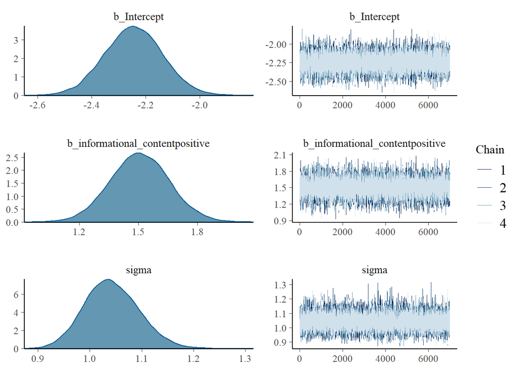

```r
plot(fit_confirmatory_intentions_deepfaked_aware, ask = FALSE)
```

### Check informativeness of prior

Using Gelman’s (2019) simple heuristic: For each parameter, compare the posterior sd to the prior sd. If the posterior sd for any parameter is more than 0.1 times the prior sd, then note that the prior was informative.

```r
check_prior(fit_confirmatory_intentions_deepfaked_aware) %>%
  kable() %>%
  kable_styling(bootstrap_options = c("striped", "hover", "condensed"),
                full_width = FALSE)
```

| Parameter | Prior_Quality |
| --- | --- |
| b_Intercept | uninformative |
| b_informational_contentpositive | uninformative |

### Interpret posteriors

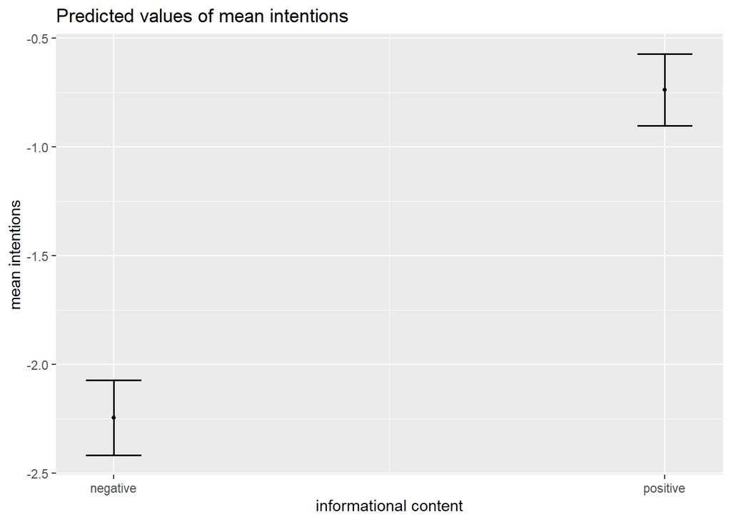

```r
#plot_model(fit_confirmatory_intentions_deepfaked_aware)
plot_model(fit_confirmatory_intentions_deepfaked_aware, type = "pred", terms = "informational_content")
```

```r
# results table
draws_intentions_deepfaked_aware <-
  select(spread_draws(fit_confirmatory_intentions_deepfaked_aware, b_informational_contentpositive), b_informational_contentpositive) %>%
  rename(effect_deepfaked_aware = b_informational_contentpositive)

estimates_intentions_deepfaked_aware <-
  map_estimate(draws_intentions_deepfaked_aware) %>%
  full_join(bayestestR::hdi(draws_intentions_deepfaked_aware, ci = .95) %>%
              rename(CI_95_lower = CI_low,
                     CI_95_upper = CI_high) %>%
              as_tibble(),
            by = "Parameter") %>%
  full_join(bayestestR::hdi(draws_intentions_deepfaked_aware, ci = .90) %>%
              as_tibble() %>%
              rename(CI_90_lower = CI_low,
                     CI_90_upper = CI_high),
            by = "Parameter") %>%
  full_join(draws_intentions_deepfaked_aware %>%
              gather(Parameter, value) %>%
              group_by(Parameter) %>%
              summarize(pd = mean(value > 0)) %>%
              mutate(p = pd_to_p(pd, direction = "one-sided")) %>%
              ungroup() %>%
              select(Parameter, p),
            by = "Parameter") %>%
  select(Parameter, MAP_Estimate, CI_95_lower, CI_95_upper,
         CI_90_lower, CI_90_upper, p)

bind_rows(filter(estimates_intentions, Parameter %in% c("effect_deepfaked")),
          estimates_intentions_deepfaked_aware) %>%
  mutate_at(.vars = c("MAP_Estimate", "CI_95_lower", "CI_95_upper", "CI_90_lower", "CI_90_upper"), round, digits = 2) %>%
  kable() %>%
  kable_styling(bootstrap_options = c("striped", "hover", "condensed"),
                full_width = FALSE)
```

| Parameter | MAP_Estimate | CI_95_lower | CI_95_upper | CI_90_lower | CI_90_upper | p |
| --- | --- | --- | --- | --- | --- | --- |
| effect_deepfaked | 1.69 | 1.49 | 1.92 | 1.52 | 1.87 | 0 |
| effect_deepfaked_aware | 1.50 | 1.22 | 1.81 | 1.26 | 1.75 | 0 |

```r
# hypothesis testing
H5c <- ifelse((estimates_intentions_deepfaked_aware %>% filter(Parameter == "effect_deepfaked_aware") %>%
                 pull(CI_95_lower)) > 0,
              "Accepted", "Rejected")
```

*H5c*

- Result: Accepted

# RQ6: Does detecting that one was exposed to a Deepfake make people immune to its influence?

Subset who received deepfaked videos but also detected them. Same Bayesian multilevel models as employed above, using only informational_content as IV, i.e., to detect whether learning effects are credibly non-zero in this subset.

## Sample sizes

```r
data_detectors_subset_n <- data_after_exclusions %>%
  filter(content_type == "deepfaked" & deepfake_detection_closed == "deepfaked") %>%
  count(deepfake_detection_closed) %>%
  mutate(proportion = round(n/sum(n), 2)) %>%
  arrange(desc(proportion))

data_detectors_subset_n %>%
  kable() %>%
  kable_styling(bootstrap_options = c("striped", "hover", "condensed"),
                full_width = FALSE)
```

| deepfake_detection_closed | n | proportion |
| --- | --- | --- |
| deepfaked | 221 | 1 |

```r
data_detectors_subset <- data_after_exclusions %>%
  filter(content_type == "deepfaked" & deepfake_detection_closed == "deepfaked")
```

## Self-reported evaluations

### Fit model

```r
fit_confirmatory_selfreport_deepfaked_detected <-
  brm(formula = mean_self_reported_evaluation ~ informational_content,
      family  = gaussian(),
      data    = data_detectors_subset,
      file    = "models/fit_confirmatory_selfreport_deepfaked_detected",
      prior   = prior(normal(0, 10)),
      iter    = 10000,
      warmup  = 3000,
      control = list(adapt_delta = 0.99),  # to avoid divergent transitions
      chains  = 4,
      cores   = parallel::detectCores())
```

### Inspect convergence

```r
summary(fit_confirmatory_selfreport_deepfaked_detected)
```

```
##  Family: gaussian
##   Links: mu = identity; sigma = identity
## Formula: mean_self_reported_evaluation ~ informational_content
##    Data: data_detectors_subset (Number of observations: 221)
##   Draws: 4 chains, each with iter = 10000; warmup = 3000; thin = 1;
##          total post-warmup draws = 28000
##
## Population-Level Effects:
##                               Estimate Est.Error l-95% CI u-95% CI Rhat
## Intercept                        -1.40      0.09    -1.58    -1.22 1.00
## informational_contentpositive     2.19      0.13     1.93     2.44 1.00
##                               Bulk_ESS Tail_ESS
## Intercept                        20894    16961
## informational_contentpositive    21073    17154
##
## Family Specific Parameters:
##       Estimate Est.Error l-95% CI u-95% CI Rhat Bulk_ESS Tail_ESS
## sigma     0.98      0.05     0.89     1.08 1.00    21916    17701
##
## Draws were sampled using sampling(NUTS). For each parameter, Bulk_ESS
## and Tail_ESS are effective sample size measures, and Rhat is the potential
## scale reduction factor on split chains (at convergence, Rhat = 1).
```

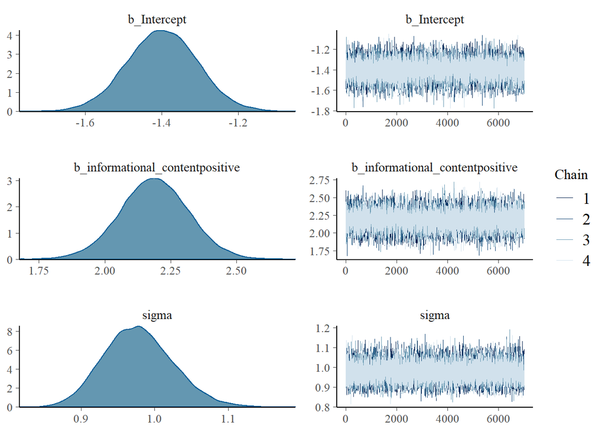

```r
plot(fit_confirmatory_selfreport_deepfaked_detected, ask = FALSE)
```

### Check informativeness of prior

Using Gelman’s (2019) simple heuristic: For each parameter, compare the posterior sd to the prior sd. If the posterior sd for any parameter is more than 0.1 times the prior sd, then note that the prior was informative.

```r
check_prior(fit_confirmatory_selfreport_deepfaked_detected) %>%
  kable() %>%
  kable_styling(bootstrap_options = c("striped", "hover", "condensed"),
                full_width = FALSE)
```

| Parameter | Prior_Quality |
| --- | --- |
| b_Intercept | uninformative |
| b_informational_contentpositive | uninformative |

### Interpret posteriors

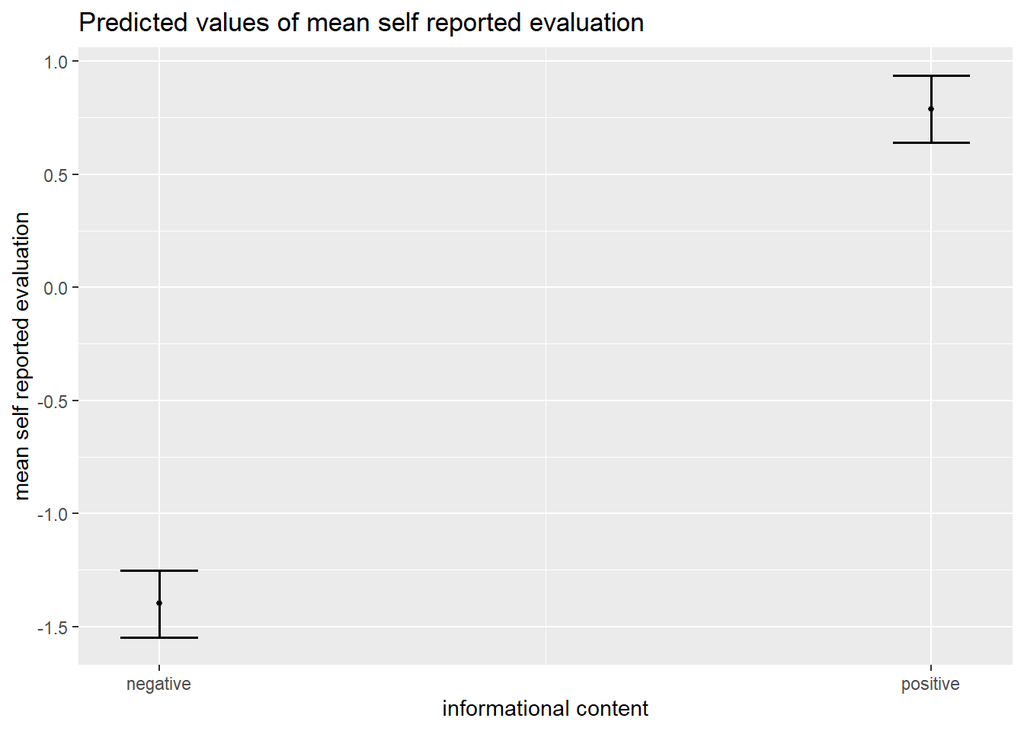

```r
#plot_model(fit_confirmatory_selfreport_deepfaked_detected)
plot_model(fit_confirmatory_selfreport_deepfaked_detected, type = "pred", terms = "informational_content")
```

```r
# results table
draws_sr_deepfaked_detected <-
  select(spread_draws(fit_confirmatory_selfreport_deepfaked_detected, b_informational_contentpositive), b_informational_contentpositive) %>%
  rename(effect_deepfaked_detected = b_informational_contentpositive)

estimates_sr_deepfaked_detected <-
  map_estimate(draws_sr_deepfaked_detected) %>%
  full_join(bayestestR::hdi(draws_sr_deepfaked_detected, ci = .95) %>%
              rename(CI_95_lower = CI_low,
                     CI_95_upper = CI_high) %>%
              as_tibble(),
            by = "Parameter") %>%
  full_join(bayestestR::hdi(draws_sr_deepfaked_detected, ci = .90) %>%
              as_tibble() %>%
              rename(CI_90_lower = CI_low,
                     CI_90_upper = CI_high),
            by = "Parameter") %>%
  full_join(draws_sr_deepfaked_detected %>%
              gather(Parameter, value) %>%
              group_by(Parameter) %>%
              summarize(pd = mean(value > 0)) %>%
              mutate(p = pd_to_p(pd, direction = "one-sided")) %>%
              ungroup() %>%
              select(Parameter, p),
            by = "Parameter") %>%
  select(Parameter, MAP_Estimate, CI_95_lower, CI_95_upper,
         CI_90_lower, CI_90_upper, p)

bind_rows(filter(estimates_sr, Parameter %in% c("effect_deepfaked")),
          estimates_sr_deepfaked_detected) %>%
  mutate_at(.vars = c("MAP_Estimate", "CI_95_lower", "CI_95_upper", "CI_90_lower", "CI_90_upper"), round, digits = 2) %>%
  kable() %>%
  kable_styling(bootstrap_options = c("striped", "hover", "condensed"),
                full_width = FALSE)
```

| Parameter | MAP_Estimate | CI_95_lower | CI_95_upper | CI_90_lower | CI_90_upper | p |
| --- | --- | --- | --- | --- | --- | --- |
| effect_deepfaked | 2.38 | 2.15 | 2.58 | 2.19 | 2.55 | 0 |
| effect_deepfaked_detected | 2.19 | 1.93 | 2.44 | 1.98 | 2.40 | 0 |

```r
# hypothesis testing
H6a <- ifelse((estimates_sr_deepfaked_detected %>% filter(Parameter == "effect_deepfaked_detected") %>%
                 pull(CI_95_lower)) > 0,
              "Accepted", "Rejected")
```

*H6a*

In the subset of participants who were shown a Deepfaked video and accurately detected that the video was Deepfaked, the content of the Deepfaked videos (i.e., Source Valence) will influence participants’ self-reported evaluations.

- Result: Accepted

## Implicit

### Fit model

```r
fit_confirmatory_implicit_deepfaked_detected <-
  brm(formula = IAT_D2 ~ informational_content,
      family  = gaussian(),
      data    = data_detectors_subset,
      file    = "models/fit_confirmatory_implicit_deepfaked_detected",
      prior   = prior(normal(0, 10)),
      iter    = 10000,
      warmup  = 3000,
      control = list(adapt_delta = 0.99),  # to avoid divergent transitions
      chains  = 4,
      cores   = parallel::detectCores())
```

### Inspect convergence

```r
summary(fit_confirmatory_implicit_deepfaked_detected)
```

```
##  Family: gaussian
##   Links: mu = identity; sigma = identity
## Formula: IAT_D2 ~ informational_content
##    Data: data_detectors_subset (Number of observations: 221)
##   Draws: 4 chains, each with iter = 10000; warmup = 3000; thin = 1;
##          total post-warmup draws = 28000
##
## Population-Level Effects:
##                               Estimate Est.Error l-95% CI u-95% CI Rhat
## Intercept                         0.13      0.09    -0.06     0.31 1.00
## informational_contentpositive     1.37      0.13     1.12     1.63 1.00
##                               Bulk_ESS Tail_ESS
## Intercept                        21741    16345
## informational_contentpositive    21860    17487
##
## Family Specific Parameters:
##       Estimate Est.Error l-95% CI u-95% CI Rhat Bulk_ESS Tail_ESS
## sigma     0.99      0.05     0.90     1.08 1.00    21736    16442
##
## Draws were sampled using sampling(NUTS). For each parameter, Bulk_ESS
## and Tail_ESS are effective sample size measures, and Rhat is the potential
## scale reduction factor on split chains (at convergence, Rhat = 1).
```

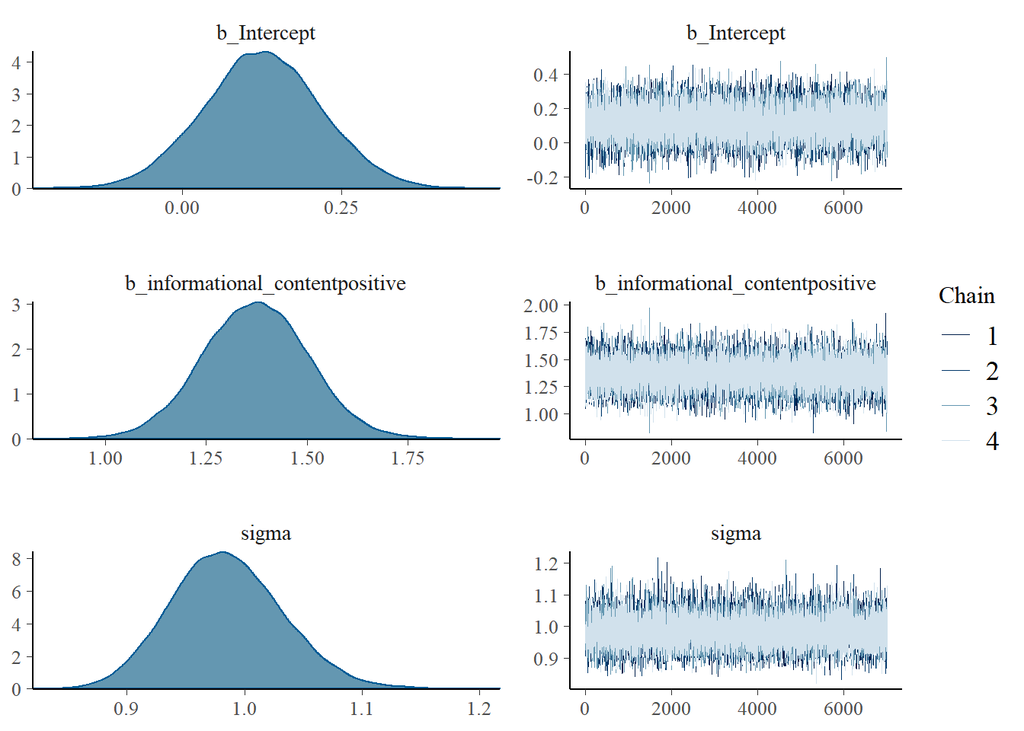

```r
plot(fit_confirmatory_implicit_deepfaked_detected, ask = FALSE)
```

### Check informativeness of prior

Using Gelman’s (2019) simple heuristic: For each parameter, compare the posterior sd to the prior sd. If the posterior sd for any parameter is more than 0.1 times the prior sd, then note that the prior was informative.

```r
check_prior(fit_confirmatory_implicit_deepfaked_detected) %>%
  kable() %>%
  kable_styling(bootstrap_options = c("striped", "hover", "condensed"),
                full_width = FALSE)
```

| Parameter | Prior_Quality |
| --- | --- |
| b_Intercept | uninformative |
| b_informational_contentpositive | uninformative |

### Interpret posteriors

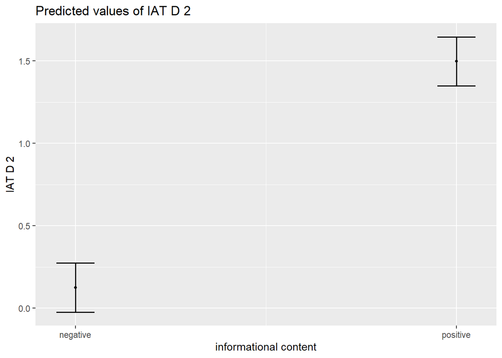

```r
#plot_model(fit_confirmatory_implicit_deepfaked_detected)
plot_model(fit_confirmatory_implicit_deepfaked_detected, type = "pred", terms = "informational_content")
```

```r
# results table
draws_imp_deepfaked_detected <-
  select(spread_draws(fit_confirmatory_implicit_deepfaked_detected, b_informational_contentpositive), b_informational_contentpositive) %>%
  rename(effect_deepfaked_detected = b_informational_contentpositive)

estimates_imp_deepfaked_detected <-
  map_estimate(draws_imp_deepfaked_detected) %>%
  full_join(bayestestR::hdi(draws_imp_deepfaked_detected, ci = .95) %>%
              rename(CI_95_lower = CI_low,
                     CI_95_upper = CI_high) %>%
              as_tibble(),
            by = "Parameter") %>%
  full_join(bayestestR::hdi(draws_imp_deepfaked_detected, ci = .90) %>%
              as_tibble() %>%
              rename(CI_90_lower = CI_low,
                     CI_90_upper = CI_high),
            by = "Parameter") %>%
  full_join(draws_imp_deepfaked_detected %>%
              gather(Parameter, value) %>%
              group_by(Parameter) %>%
              summarize(pd = mean(value > 0)) %>%
              mutate(p = pd_to_p(pd, direction = "one-sided")) %>%
              ungroup() %>%
              select(Parameter, p),
            by = "Parameter") %>%
  select(Parameter, MAP_Estimate, CI_95_lower, CI_95_upper,
         CI_90_lower, CI_90_upper, p)

bind_rows(filter(estimates_imp, Parameter %in% c("effect_deepfaked")),
          estimates_imp_deepfaked_detected) %>%
  mutate_at(.vars = c("MAP_Estimate", "CI_95_lower", "CI_95_upper", "CI_90_lower", "CI_90_upper"), round, digits = 2) %>%
  kable() %>%
  kable_styling(bootstrap_options = c("striped", "hover", "condensed"),
                full_width = FALSE)
```

| Parameter | MAP_Estimate | CI_95_lower | CI_95_upper | CI_90_lower | CI_90_upper | p |
| --- | --- | --- | --- | --- | --- | --- |
| effect_deepfaked | 1.37 | 1.14 | 1.57 | 1.17 | 1.53 | 0 |
| effect_deepfaked_detected | 1.38 | 1.11 | 1.62 | 1.16 | 1.59 | 0 |

```r
# hypothesis testing
H6b <- ifelse((estimates_imp_deepfaked_detected %>% filter(Parameter == "effect_deepfaked_detected") %>%
                 pull(CI_95_lower)) > 0,
              "Accepted", "Rejected")
```

*H6b*

In the subset of participants who were shown a Deepfaked video and accurately detected that the video was Deepfaked, the content of the Deepfaked videos (i.e., Source Valence) will influence participants’ IAT D2 scores.

- Result: Accepted

## Behavioural intentions

### Fit model

```r
fit_confirmatory_intentions_deepfaked_detected <-
  brm(formula = mean_intentions ~ informational_content,
      family  = gaussian(),
      data    = data_detectors_subset,
      file    = "models/fit_confirmatory_intentions_deepfaked_detected",
      prior   = prior(normal(0, 10)),
      iter    = 10000,
      warmup  = 3000,
      control = list(adapt_delta = 0.99),  # to avoid divergent transitions
      chains  = 4,
      cores   = parallel::detectCores())
```

### Inspect convergence

```r
summary(fit_confirmatory_intentions_deepfaked_detected)
```

```
##  Family: gaussian
##   Links: mu = identity; sigma = identity
## Formula: mean_intentions ~ informational_content
##    Data: data_detectors_subset (Number of observations: 221)
##   Draws: 4 chains, each with iter = 10000; warmup = 3000; thin = 1;
##          total post-warmup draws = 28000
##
## Population-Level Effects:
##                               Estimate Est.Error l-95% CI u-95% CI Rhat
## Intercept                        -2.37      0.09    -2.55    -2.19 1.00
## informational_contentpositive     1.59      0.13     1.34     1.84 1.00
##                               Bulk_ESS Tail_ESS
## Intercept                        22120    17323
## informational_contentpositive    21605    16707
##
## Family Specific Parameters:
##       Estimate Est.Error l-95% CI u-95% CI Rhat Bulk_ESS Tail_ESS
## sigma     0.96      0.05     0.87     1.05 1.00    21701    17949
##
## Draws were sampled using sampling(NUTS). For each parameter, Bulk_ESS
## and Tail_ESS are effective sample size measures, and Rhat is the potential
## scale reduction factor on split chains (at convergence, Rhat = 1).
```

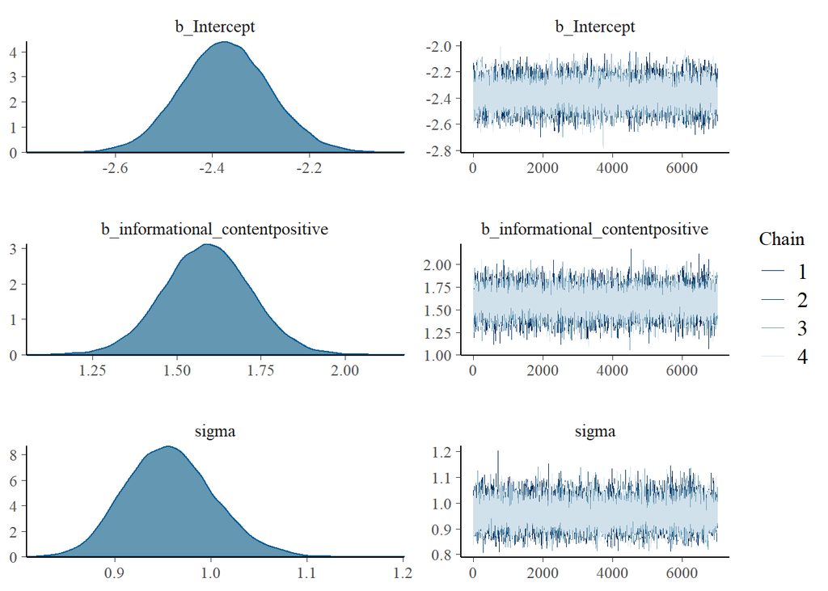

```r
plot(fit_confirmatory_intentions_deepfaked_detected, ask = FALSE)
```

### Check informativeness of prior

Using Gelman’s (2019) simple heuristic: For each parameter, compare the posterior sd to the prior sd. If the posterior sd for any parameter is more than 0.1 times the prior sd, then note that the prior was informative.

```r
check_prior(fit_confirmatory_intentions_deepfaked_detected) %>%
  kable() %>%
  kable_styling(bootstrap_options = c("striped", "hover", "condensed"),
                full_width = FALSE)
```

| Parameter | Prior_Quality |
| --- | --- |
| b_Intercept | uninformative |
| b_informational_contentpositive | uninformative |

### Interpret posteriors

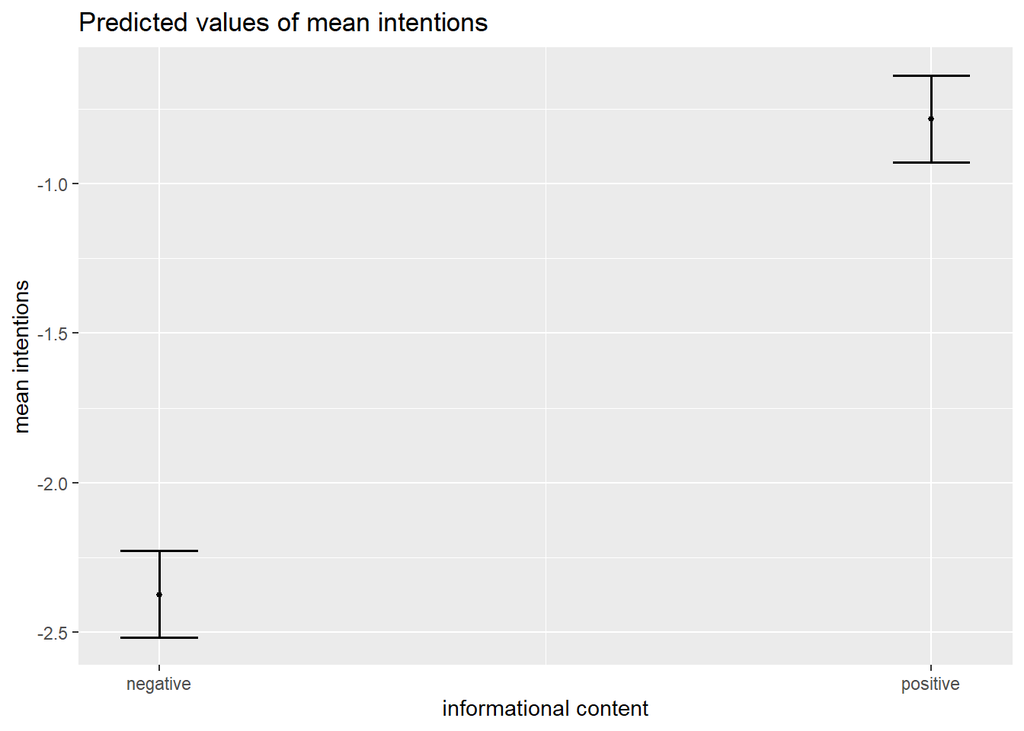

```r
#plot_model(fit_confirmatory_intentions_deepfaked_detected)
plot_model(fit_confirmatory_intentions_deepfaked_detected, type = "pred", terms = "informational_content")
```

```r
# results table
draws_intentions_deepfaked_detected <-
  select(spread_draws(fit_confirmatory_intentions_deepfaked_detected, b_informational_contentpositive), b_informational_contentpositive) %>%
  rename(effect_deepfaked_detected = b_informational_contentpositive)

estimates_intentions_deepfaked_detected <-
  map_estimate(draws_intentions_deepfaked_detected) %>%
  full_join(bayestestR::hdi(draws_intentions_deepfaked_detected, ci = .95) %>%
              rename(CI_95_lower = CI_low,
                     CI_95_upper = CI_high) %>%
              as_tibble(),
            by = "Parameter") %>%
  full_join(bayestestR::hdi(draws_intentions_deepfaked_detected, ci = .90) %>%
              as_tibble() %>%
              rename(CI_90_lower = CI_low,
                     CI_90_upper = CI_high),
            by = "Parameter") %>%
  full_join(draws_intentions_deepfaked_detected %>%
              gather(Parameter, value) %>%
              group_by(Parameter) %>%
              summarize(pd = mean(value > 0)) %>%
              mutate(p = pd_to_p(pd, direction = "one-sided")) %>%
              ungroup() %>%
              select(Parameter, p),
            by = "Parameter") %>%
  select(Parameter, MAP_Estimate, CI_95_lower, CI_95_upper,
         CI_90_lower, CI_90_upper, p)

bind_rows(filter(estimates_intentions, Parameter %in% c("effect_deepfaked")),
          estimates_intentions_deepfaked_detected) %>%
  mutate_at(.vars = c("MAP_Estimate", "CI_95_lower", "CI_95_upper", "CI_90_lower", "CI_90_upper"), round, digits = 2) %>%
  kable() %>%
  kable_styling(bootstrap_options = c("striped", "hover", "condensed"),
                full_width = FALSE)
```

| Parameter | MAP_Estimate | CI_95_lower | CI_95_upper | CI_90_lower | CI_90_upper | p |
| --- | --- | --- | --- | --- | --- | --- |
| effect_deepfaked | 1.69 | 1.49 | 1.92 | 1.52 | 1.87 | 0 |
| effect_deepfaked_detected | 1.59 | 1.33 | 1.84 | 1.38 | 1.80 | 0 |

```r
# hypothesis testing
H6c <- ifelse((estimates_intentions_deepfaked_detected %>% filter(Parameter == "effect_deepfaked_detected") %>%
                 pull(CI_95_lower)) > 0,
              "Accepted", "Rejected")
```

*H6c*

In the subset of participants who were shown a Deepfaked video and accurately detected that the video was Deepfaked, the content of the Deepfaked videos (i.e., Source Valence) will influence participants’ behavioral intention scores.

- Result: Accepted

# RQ7: Does being both aware of the concept of Deepfaking before the study and correcting detecting that content is Deepfaked make you immune to its influence?

Subset who received deepfaked videos, were aware of the concept before the study, and also detected them. Same Bayesian multilevel models as employed above, using only informational_content as IV, i.e., to detect whether learning effects are credibly non-zero in this subset.

## Sample sizes

```r
data_aware_detectors_subset_n <- data_after_exclusions %>%
  filter(content_type == "deepfaked" &
           deepfake_detection_closed == "deepfaked" &
           deepfake_awareness_closed == "aware") %>%
  count(deepfake_detection_closed, deepfake_awareness_closed) %>%
  mutate(proportion = round(n/sum(n), 2)) %>%
  arrange(desc(proportion))

data_aware_detectors_subset_n %>%
  kable() %>%
  kable_styling(bootstrap_options = c("striped", "hover", "condensed"),
                full_width = FALSE)
```

| deepfake_detection_closed | deepfake_awareness_closed | n | proportion |
| --- | --- | --- | --- |
| deepfaked | aware | 145 | 1 |

```r
data_aware_detectors_subset <- data_after_exclusions %>%
  filter(content_type == "deepfaked" &
           deepfake_detection_closed == "deepfaked" &
           deepfake_awareness_closed == "aware")
```

## Self-reported evaluations

### Fit model

```r
fit_confirmatory_selfreport_deepfaked_aware_detected <-
  brm(formula = mean_self_reported_evaluation ~ informational_content,
      family  = gaussian(),
      data    = data_aware_detectors_subset,
      file    = "models/fit_confirmatory_selfreport_deepfaked_aware_detected",
      prior   = prior(normal(0, 10)),
      iter    = 10000,
      warmup  = 3000,
      control = list(adapt_delta = 0.99),  # to avoid divergent transitions
      chains  = 4,
      cores   = parallel::detectCores())
```

### Inspect convergence

```r
summary(fit_confirmatory_selfreport_deepfaked_aware_detected)
```

```
##  Family: gaussian
##   Links: mu = identity; sigma = identity
## Formula: mean_self_reported_evaluation ~ informational_content
##    Data: data_aware_detectors_subset (Number of observations: 145)
##   Draws: 4 chains, each with iter = 10000; warmup = 3000; thin = 1;
##          total post-warmup draws = 28000
##
## Population-Level Effects:
##                               Estimate Est.Error l-95% CI u-95% CI Rhat
## Intercept                        -1.28      0.11    -1.51    -1.06 1.00
## informational_contentpositive     1.97      0.16     1.65     2.28 1.00
##                               Bulk_ESS Tail_ESS
## Intercept                        20965    15406
## informational_contentpositive    20182    16061
##
## Family Specific Parameters:
##       Estimate Est.Error l-95% CI u-95% CI Rhat Bulk_ESS Tail_ESS
## sigma     0.96      0.06     0.85     1.08 1.00    19856    15963
##
## Draws were sampled using sampling(NUTS). For each parameter, Bulk_ESS
## and Tail_ESS are effective sample size measures, and Rhat is the potential
## scale reduction factor on split chains (at convergence, Rhat = 1).
```

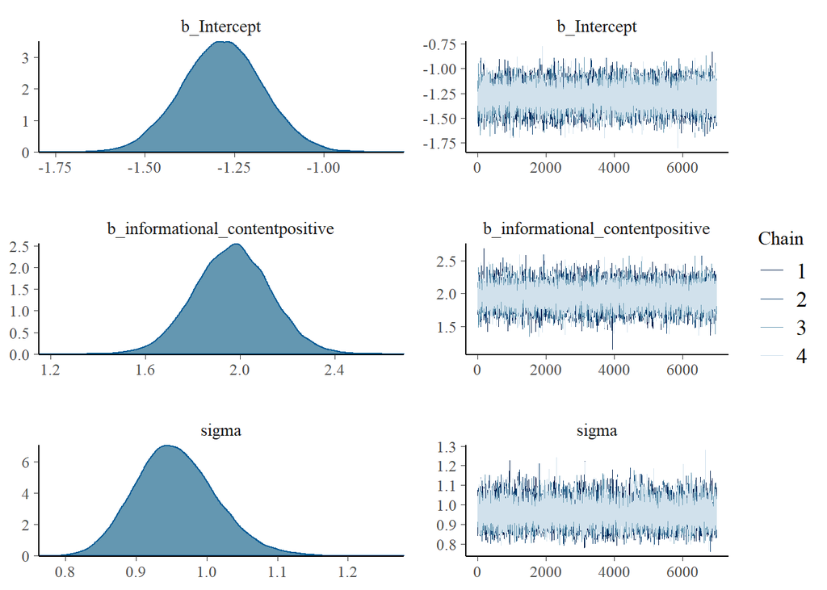

```r
plot(fit_confirmatory_selfreport_deepfaked_aware_detected, ask = FALSE)
```

### Check informativeness of prior

Using Gelman’s (2019) simple heuristic: For each parameter, compare the posterior sd to the prior sd. If the posterior sd for any parameter is more than 0.1 times the prior sd, then note that the prior was informative.

```r
check_prior(fit_confirmatory_selfreport_deepfaked_aware_detected) %>%
  kable() %>%
  kable_styling(bootstrap_options = c("striped", "hover", "condensed"),
                full_width = FALSE)
```

| Parameter | Prior_Quality |
| --- | --- |
| b_Intercept | uninformative |
| b_informational_contentpositive | uninformative |

### Interpret posteriors

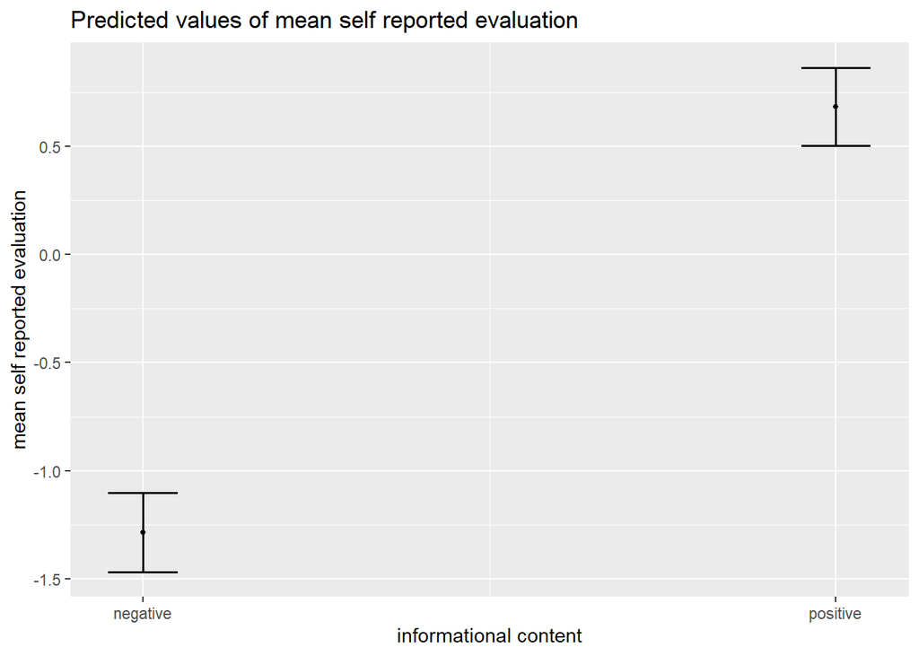

```r
#plot_model(fit_confirmatory_selfreport_deepfaked_aware_detected)
plot_model(fit_confirmatory_selfreport_deepfaked_aware_detected, type = "pred", terms = "informational_content")
```

```r
# results table
draws_sr_deepfaked_aware_detected <-
  select(spread_draws(fit_confirmatory_selfreport_deepfaked_aware_detected, b_informational_contentpositive), b_informational_contentpositive) %>%
  rename(effect_deepfaked_aware_detected = b_informational_contentpositive)

estimates_sr_deepfaked_aware_detected <-
  map_estimate(draws_sr_deepfaked_aware_detected) %>%
  full_join(bayestestR::hdi(draws_sr_deepfaked_aware_detected, ci = .95) %>%
              rename(CI_95_lower = CI_low,
                     CI_95_upper = CI_high) %>%
              as_tibble(),
            by = "Parameter") %>%
  full_join(bayestestR::hdi(draws_sr_deepfaked_aware_detected, ci = .90) %>%
              as_tibble() %>%
              rename(CI_90_lower = CI_low,
                     CI_90_upper = CI_high),
            by = "Parameter") %>%
  full_join(draws_sr_deepfaked_aware_detected %>%
              gather(Parameter, value) %>%
              group_by(Parameter) %>%
              summarize(pd = mean(value > 0)) %>%
              mutate(p = pd_to_p(pd, direction = "one-sided")) %>%
              ungroup() %>%
              select(Parameter, p),
            by = "Parameter") %>%
  select(Parameter, MAP_Estimate, CI_95_lower, CI_95_upper,
         CI_90_lower, CI_90_upper, p)

bind_rows(filter(estimates_sr, Parameter %in% c("effect_deepfaked")),
          estimates_sr_deepfaked_aware_detected) %>%
  mutate_at(.vars = c("MAP_Estimate", "CI_95_lower", "CI_95_upper", "CI_90_lower", "CI_90_upper"), round, digits = 2) %>%
  kable() %>%
  kable_styling(bootstrap_options = c("striped", "hover", "condensed"),
                full_width = FALSE)
```

| Parameter | MAP_Estimate | CI_95_lower | CI_95_upper | CI_90_lower | CI_90_upper | p |
| --- | --- | --- | --- | --- | --- | --- |
| effect_deepfaked | 2.38 | 2.15 | 2.58 | 2.19 | 2.55 | 0 |
| effect_deepfaked_aware_detected | 1.98 | 1.65 | 2.28 | 1.71 | 2.23 | 0 |

```r
# hypothesis testing
H7a <- ifelse((estimates_sr_deepfaked_aware_detected %>% filter(Parameter == "effect_deepfaked_aware_detected") %>%
                 pull(CI_95_lower)) > 0,
              "Accepted", "Rejected")
```

*H7a*

In the subset of participants who were shown a Deepfaked video, reported being aware of the concept of Deepfakes, and accurately detected that the video was Deepfaked, the content of the Deepfaked videos (i.e., Source Valence) will influence participants’ self-reported evaluations.

- Result: Accepted

## Implicit

### Fit model

```r
fit_confirmatory_implicit_deepfaked_aware_detected <-
  brm(formula = IAT_D2 ~ informational_content,
      family  = gaussian(),
      data    = data_aware_detectors_subset,
      file    = "models/fit_confirmatory_implicit_deepfaked_aware_detected",
      prior   = prior(normal(0, 10)),
      iter    = 10000,
      warmup  = 3000,
      control = list(adapt_delta = 0.99),  # to avoid divergent transitions
      chains  = 4,
      cores   = parallel::detectCores())
```

### Inspect convergence

```r
summary(fit_confirmatory_implicit_deepfaked_aware_detected)
```

```
##  Family: gaussian
##   Links: mu = identity; sigma = identity
## Formula: IAT_D2 ~ informational_content
##    Data: data_aware_detectors_subset (Number of observations: 145)
##   Draws: 4 chains, each with iter = 10000; warmup = 3000; thin = 1;
##          total post-warmup draws = 28000
##
## Population-Level Effects:
##                               Estimate Est.Error l-95% CI u-95% CI Rhat
## Intercept                         0.18      0.12    -0.05     0.42 1.00
## informational_contentpositive     1.33      0.17     1.00     1.66 1.00
##                               Bulk_ESS Tail_ESS
## Intercept                        19102    16544
## informational_contentpositive    18632    15535
##
## Family Specific Parameters:
##       Estimate Est.Error l-95% CI u-95% CI Rhat Bulk_ESS Tail_ESS
## sigma     0.99      0.06     0.88     1.12 1.00    19519    16938
##
## Draws were sampled using sampling(NUTS). For each parameter, Bulk_ESS
## and Tail_ESS are effective sample size measures, and Rhat is the potential
## scale reduction factor on split chains (at convergence, Rhat = 1).
```

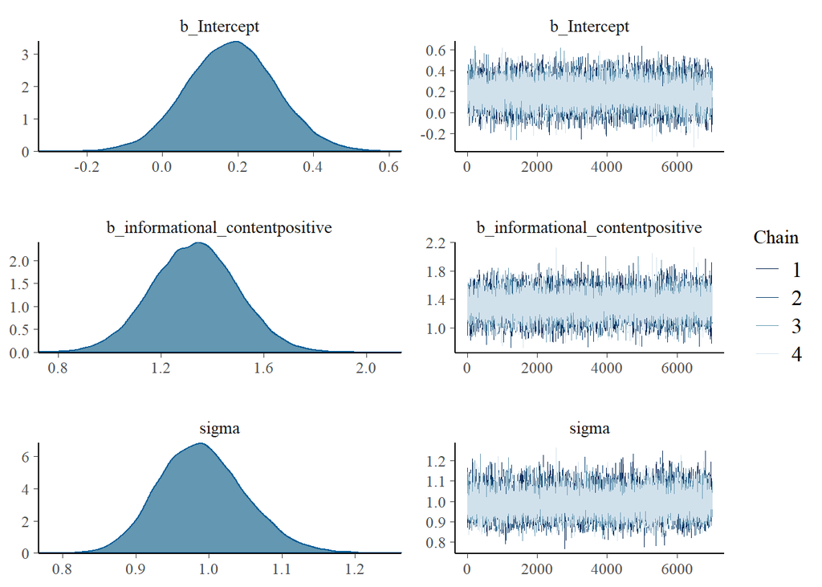

```r
plot(fit_confirmatory_implicit_deepfaked_aware_detected, ask = FALSE)
```

### Check informativeness of prior

Using Gelman’s (2019) simple heuristic: For each parameter, compare the posterior sd to the prior sd. If the posterior sd for any parameter is more than 0.1 times the prior sd, then note that the prior was informative.

```r
check_prior(fit_confirmatory_implicit_deepfaked_aware_detected) %>%
  kable() %>%
  kable_styling(bootstrap_options = c("striped", "hover", "condensed"),
                full_width = FALSE)
```

| Parameter | Prior_Quality |
| --- | --- |
| b_Intercept | uninformative |
| b_informational_contentpositive | uninformative |

### Interpret posteriors

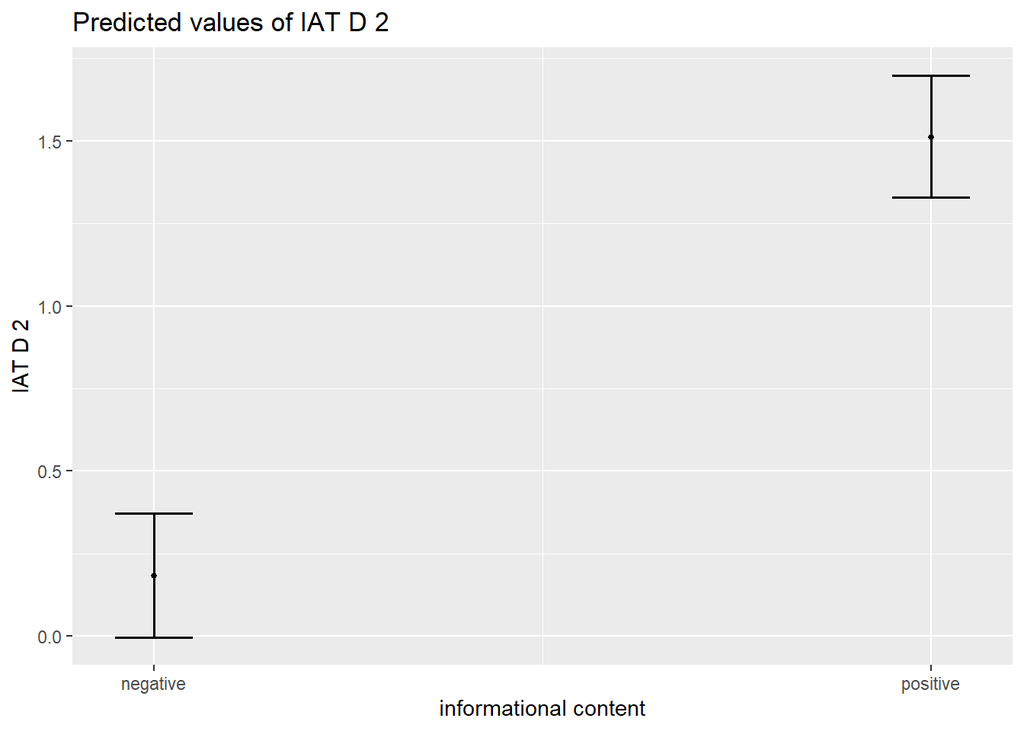

```r
#plot_model(fit_confirmatory_implicit_deepfaked_aware_detected)
plot_model(fit_confirmatory_implicit_deepfaked_aware_detected, type = "pred", terms = "informational_content")
```

```r
# results table
draws_imp_deepfaked_aware_detected <-
  select(spread_draws(fit_confirmatory_implicit_deepfaked_aware_detected, b_informational_contentpositive), b_informational_contentpositive) %>%
  rename(effect_deepfaked_aware_detected = b_informational_contentpositive)

estimates_imp_deepfaked_aware_detected <-
  map_estimate(draws_imp_deepfaked_aware_detected) %>%
  full_join(bayestestR::hdi(draws_imp_deepfaked_aware_detected, ci = .95) %>%
              rename(CI_95_lower = CI_low,
                     CI_95_upper = CI_high) %>%
              as_tibble(),
            by = "Parameter") %>%
  full_join(bayestestR::hdi(draws_imp_deepfaked_aware_detected, ci = .90) %>%
              as_tibble() %>%
              rename(CI_90_lower = CI_low,
                     CI_90_upper = CI_high),
            by = "Parameter") %>%
  full_join(draws_imp_deepfaked_aware_detected %>%
              gather(Parameter, value) %>%
              group_by(Parameter) %>%
              summarize(pd = mean(value > 0)) %>%
              mutate(p = pd_to_p(pd, direction = "one-sided")) %>%
              ungroup() %>%
              select(Parameter, p),
            by = "Parameter") %>%
  select(Parameter, MAP_Estimate, CI_95_lower, CI_95_upper,
         CI_90_lower, CI_90_upper, p)

bind_rows(filter(estimates_imp, Parameter %in% c("effect_deepfaked")),
          estimates_imp_deepfaked_aware_detected) %>%
  mutate_at(.vars = c("MAP_Estimate", "CI_95_lower", "CI_95_upper", "CI_90_lower", "CI_90_upper"), round, digits = 2) %>%
  kable() %>%
  kable_styling(bootstrap_options = c("striped", "hover", "condensed"),
                full_width = FALSE)
```

| Parameter | MAP_Estimate | CI_95_lower | CI_95_upper | CI_90_lower | CI_90_upper | p |
| --- | --- | --- | --- | --- | --- | --- |
| effect_deepfaked | 1.37 | 1.14 | 1.57 | 1.17 | 1.53 | 0 |
| effect_deepfaked_aware_detected | 1.35 | 1.01 | 1.66 | 1.06 | 1.60 | 0 |

```r
# hypothesis testing
H7b <- ifelse((estimates_imp_deepfaked_aware_detected %>% filter(Parameter == "effect_deepfaked_aware_detected") %>%
                 pull(CI_95_lower)) > 0,
              "Accepted", "Rejected")
```

*H7b*

In the subset of participants who were shown a Deepfaked video, reported being aware of the concept of Deepfakes, and accurately detected that the video was Deepfaked, the content of the Deepfaked videos (i.e., Source Valence) will influence participants’ IAT D2 scores.

- Result: Accepted

## Behavioural intentions

### Fit model

```r
fit_confirmatory_intentions_deepfaked_aware_detected <-
  brm(formula = mean_intentions ~ informational_content,
      family  = gaussian(),
      data    = data_aware_detectors_subset,
      file    = "models/fit_confirmatory_intentions_deepfaked_aware_detected",
      prior   = prior(normal(0, 10)),
      iter    = 10000,
      warmup  = 3000,
      control = list(adapt_delta = 0.99),  # to avoid divergent transitions
      chains  = 4,
      cores   = parallel::detectCores())
```

### Inspect convergence

```r
summary(fit_confirmatory_intentions_deepfaked_aware_detected)
```

```
##  Family: gaussian
##   Links: mu = identity; sigma = identity
## Formula: mean_intentions ~ informational_content
##    Data: data_aware_detectors_subset (Number of observations: 145)
##   Draws: 4 chains, each with iter = 10000; warmup = 3000; thin = 1;
##          total post-warmup draws = 28000
##
## Population-Level Effects:
##                               Estimate Est.Error l-95% CI u-95% CI Rhat
## Intercept                        -2.30      0.12    -2.52    -2.07 1.00
## informational_contentpositive     1.39      0.16     1.08     1.71 1.00
##                               Bulk_ESS Tail_ESS
## Intercept                        21547    15817
## informational_contentpositive    22032    16845
##
## Family Specific Parameters:
##       Estimate Est.Error l-95% CI u-95% CI Rhat Bulk_ESS Tail_ESS
## sigma     0.97      0.06     0.86     1.09 1.00    21375    17521
##
## Draws were sampled using sampling(NUTS). For each parameter, Bulk_ESS
## and Tail_ESS are effective sample size measures, and Rhat is the potential
## scale reduction factor on split chains (at convergence, Rhat = 1).
```

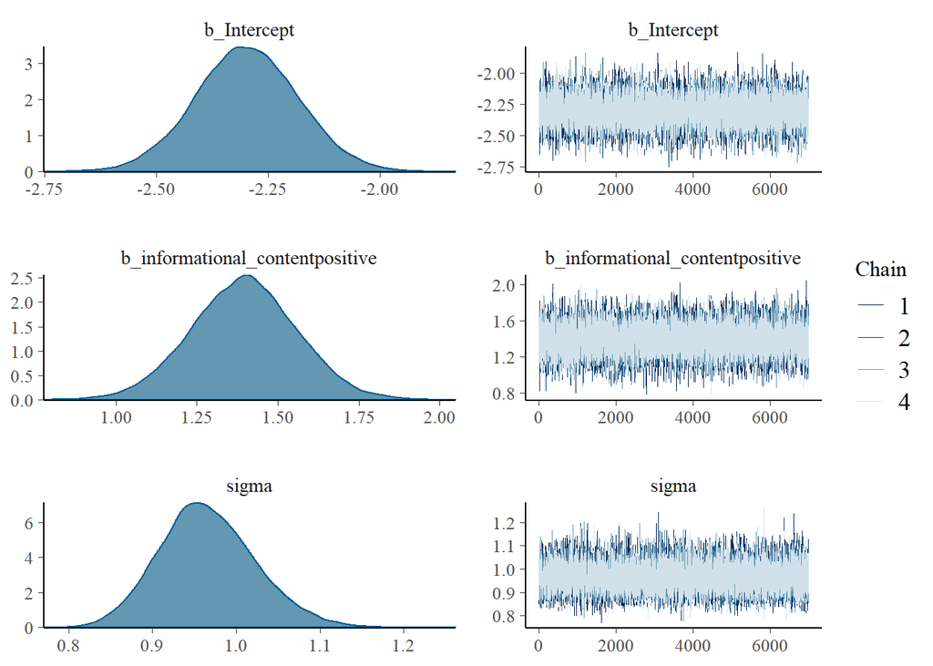

```r
plot(fit_confirmatory_intentions_deepfaked_aware_detected, ask = FALSE)
```

### Check informativeness of prior

Using Gelman’s (2019) simple heuristic: For each parameter, compare the posterior sd to the prior sd. If the posterior sd for any parameter is more than 0.1 times the prior sd, then note that the prior was informative.

```r
check_prior(fit_confirmatory_intentions_deepfaked_aware_detected) %>%
  kable() %>%
  kable_styling(bootstrap_options = c("striped", "hover", "condensed"),
                full_width = FALSE)
```

| Parameter | Prior_Quality |
| --- | --- |
| b_Intercept | uninformative |
| b_informational_contentpositive | uninformative |

### Interpret posteriors

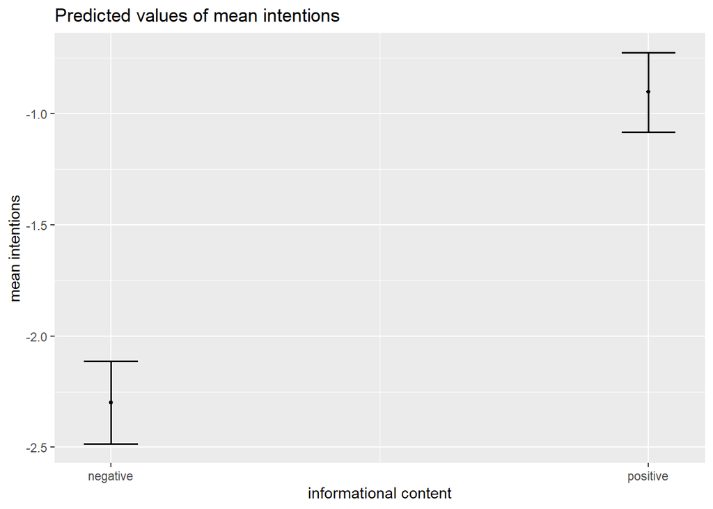

```r
#plot_model(fit_confirmatory_intentions_deepfaked_aware_detected)
plot_model(fit_confirmatory_intentions_deepfaked_aware_detected, type = "pred", terms = "informational_content")
```

```r
# results table
draws_intentions_deepfaked_aware_detected <-
  select(spread_draws(fit_confirmatory_intentions_deepfaked_aware_detected, b_informational_contentpositive), b_informational_contentpositive) %>%
  rename(effect_deepfaked_aware_detected = b_informational_contentpositive)

estimates_intentions_deepfaked_aware_detected <-
  map_estimate(draws_intentions_deepfaked_aware_detected) %>%
  full_join(bayestestR::hdi(draws_intentions_deepfaked_aware_detected, ci = .95) %>%
              rename(CI_95_lower = CI_low,
                     CI_95_upper = CI_high) %>%
              as_tibble(),
            by = "Parameter") %>%
  full_join(bayestestR::hdi(draws_intentions_deepfaked_aware_detected, ci = .90) %>%
              as_tibble() %>%
              rename(CI_90_lower = CI_low,
                     CI_90_upper = CI_high),
            by = "Parameter") %>%
  full_join(draws_intentions_deepfaked_aware_detected %>%
              gather(Parameter, value) %>%
              group_by(Parameter) %>%
              summarize(pd = mean(value > 0)) %>%
              mutate(p = pd_to_p(pd, direction = "one-sided")) %>%
              ungroup() %>%
              select(Parameter, p),
            by = "Parameter") %>%
  select(Parameter, MAP_Estimate, CI_95_lower, CI_95_upper,
         CI_90_lower, CI_90_upper, p)

bind_rows(filter(estimates_intentions, Parameter %in% c("effect_deepfaked")),
          estimates_intentions_deepfaked_aware_detected) %>%
  mutate_at(.vars = c("MAP_Estimate", "CI_95_lower", "CI_95_upper", "CI_90_lower", "CI_90_upper"), round, digits = 2) %>%
  kable() %>%
  kable_styling(bootstrap_options = c("striped", "hover", "condensed"),
                full_width = FALSE)
```

| Parameter | MAP_Estimate | CI_95_lower | CI_95_upper | CI_90_lower | CI_90_upper | p |
| --- | --- | --- | --- | --- | --- | --- |
| effect_deepfaked | 1.69 | 1.49 | 1.92 | 1.52 | 1.87 | 0 |
| effect_deepfaked_aware_detected | 1.40 | 1.08 | 1.72 | 1.13 | 1.66 | 0 |

```r
# hypothesis testing
H7c <- ifelse((estimates_intentions_deepfaked_aware_detected %>% filter(Parameter == "effect_deepfaked_aware_detected") %>%
                 pull(CI_95_lower)) > 0,
              "Accepted", "Rejected")
```

*H7c*

In the subset of participants who were shown a Deepfaked video, reported being aware of the concept of Deepfakes, and accurately detected that the video was Deepfaked, the content of the Deepfaked videos (i.e., Source Valence) will influence participants’ behavioral intention scores.

- Result: Accepted

# Summary of hypothesis tests

H1: Establishing first impressions via online video content

- Genuine content can establish self-reported evaluations (Accepted), implicit evaluations (Accepted), and behavioural intentions (Accepted).
- Deepfaked content can establish self-reported evaluations (Accepted), implicit evaluations (Accepted), and behavioural intentions (Accepted).

H2: Are deepfakes just as good as the real thing?

- Deepfakes are non-inferior to genuine content on self-reported evaluations (Rejected), implicit evaluations (Accepted), and behavioural intentions (Accepted).

H3: How good are people at detecting whether content is genuine or Deepfaked?

Whole sample

```r
classifications %>%
  kable() %>%
  kable_styling(bootstrap_options = c("striped", "hover", "condensed"),
                full_width = FALSE)
```

| variable | observed | ci_lower | ci_upper |
| --- | --- | --- | --- |
| balanced_accuracy | 0.64 | 0.60 | 0.67 |
| false_negative_rate | 0.33 | 0.28 | 0.38 |
| false_positive_rate | 0.39 | 0.34 | 0.45 |
| informedness | 0.27 | 0.20 | 0.35 |

Those who were aware of the concept prior to the study

```r
classifications_subset %>%
  kable() %>%
  kable_styling(bootstrap_options = c("striped", "hover", "condensed"),
                full_width = FALSE)
```

| variable | observed | ci_lower | ci_upper |
| --- | --- | --- | --- |
| balanced_accuracy | 0.68 | 0.63 | 0.73 |
| false_negative_rate | 0.26 | 0.20 | 0.32 |
| false_positive_rate | 0.38 | 0.31 | 0.46 |
| informedness | 0.36 | 0.26 | 0.45 |

H4: Does prior awareness of the concept of Deepfakes make people better at detecting them?

- Percent aware of the concept of Deepfakes: 56.3
- Of those exposed to a Deepfake, Individuals who were aware of the concept of Deepfakes prior to participating in the study were 1.9 times more likely to detect that they had been shown a deepfake than those who were not aware of the concept (Incidence Rate Ratio = 1.92, 95% CI [1.45, 2.51]), Accepted.

H5-7: Does being aware of the concept, detecitng the deepfake, or both make you immune to a Deepfake?